# STA206_Project

Hamidreza Attari

2024-11-17

# 1. Preparation

1. Response variables in this project are Plasma beta-carotene(“BETAPLASMA”) and Plasma Retinol(“RETPLASMA”).

## 1-1. Data Checking

```r
library(car)
library(MASS)
# loading data
data = read.table("C:/Users/hratt/Downloads/Plasma.txt", header = TRUE, sep = "", stringsAsFactors = FALSE)
# reorder variables
data = data[, c(2,3,5,1,4,6:14)]

# check data type
sapply(data, class)
```

```
##         SEX    SMOKSTAT      VITUSE         AGE    QUETELET    CALORIES
## "character" "character" "character"   "integer"   "numeric"   "numeric"
##         FAT       FIBER     ALCOHOL CHOLESTEROL    BETADIET     RETDIET
##   "numeric"   "numeric"   "numeric"   "numeric"   "integer"   "integer"
##  BETAPLASMA   RETPLASMA
##   "integer"   "integer"
```

```r
# check missing value
sapply(data, function(x) sum(is.na(x)))
```

```
##         SEX    SMOKSTAT      VITUSE         AGE    QUETELET    CALORIES
##           0           0           0           0           0           0
##         FAT       FIBER     ALCOHOL CHOLESTEROL    BETADIET     RETDIET
##           0           0           0           0           0           0
##  BETAPLASMA   RETPLASMA
##           0           0
```

We can see the database do not contain missing data.

## 1-2. Data Preprocessing

@@@ We should denote “SEX”, “SMOKSTAT”, and “VITUSE” as categorical variables and the rest variables should be quantitative variables.

```r
# transfer "SEX", "SMOKSTAT", and "VITUSE" to dummy variable
data$SEX <- as.factor(data$SEX)
data$SMOKSTAT <- as.factor(data$SMOKSTAT)
data$VITUSE <- as.factor(data$VITUSE)

levels(data$SEX)
```

```
## [1] "FEMALE" "MALE"
```

```r
levels(data$SMOKSTAT)
```

```
## [1] "CURRENT" "FORMER"  "NEVER"
```

```r
levels(data$VITUSE)
```

```
## [1] "NO"        "NOT OFTEN" "OFTEN"
```

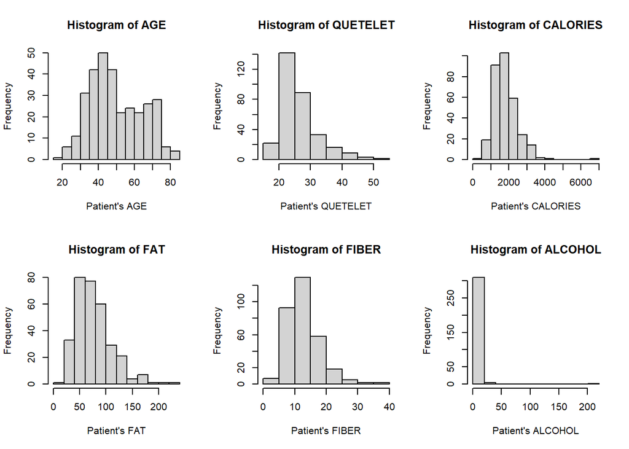

```r
# Draw plots to depict the distribution of each variable
par(mfrow = c(2, 3))
for(i in 4:14) {
hist(data[, i], main=paste("Histogram of", names(data)[i]), xlab = paste("Patient\'s", names(data)[i]))}
```

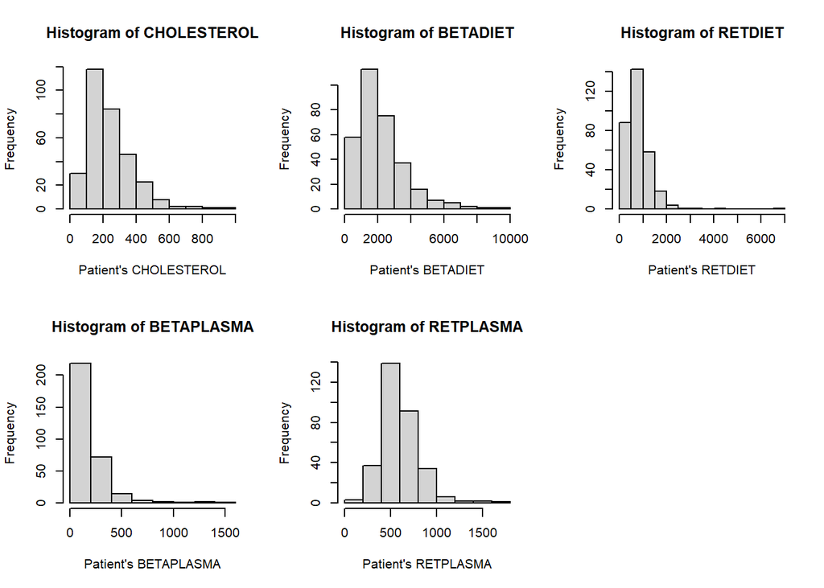

```r
par(mfrow = c(1, 1))
```

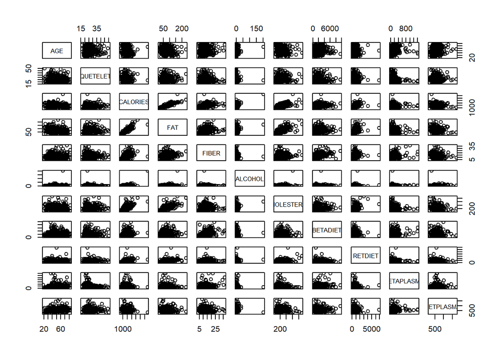

```r
pairs(data[,4:14])
```

```r
cor(data[,4:14])
```

```
##                      AGE     QUETELET     CALORIES         FAT       FIBER
## AGE          1.000000000 -0.017463821 -0.176769399 -0.16947981  0.04485175
## QUETELET    -0.017463821  1.000000000  0.003526964  0.04875033 -0.08762333
## CALORIES    -0.176769399  0.003526964  1.000000000  0.87184150  0.46548077
## FAT         -0.169479813  0.048750329  0.871841504  1.00000000  0.27648356
## FIBER        0.044851750 -0.087623326  0.465480772  0.27648356  1.00000000
## ALCOHOL      0.051583268 -0.072695431  0.451469804  0.18574310 -0.02011748
## CHOLESTEROL -0.113605966  0.110257245  0.659175452  0.70984794  0.15396838
## BETADIET     0.071869247 -0.006603005  0.243376823  0.14342785  0.48264371
## RETDIET     -0.009610795  0.032055785  0.402491661  0.41221481  0.21461162
## BETAPLASMA   0.101127650 -0.229387366 -0.022206957 -0.09164659  0.23595358
## RETPLASMA    0.211671702  0.013138652 -0.073328605 -0.09093779 -0.04443071
##                 ALCOHOL CHOLESTEROL     BETADIET      RETDIET  BETAPLASMA
## AGE          0.05158327 -0.11360597  0.071869247 -0.009610795  0.10112765
## QUETELET    -0.07269543  0.11025724 -0.006603005  0.032055785 -0.22938737
## CALORIES     0.45146980  0.65917545  0.243376823  0.402491661 -0.02220696
## FAT          0.18574310  0.70984794  0.143427853  0.412214814 -0.09164659
## FIBER       -0.02011748  0.15396838  0.482643706  0.214611616  0.23595358
## ALCOHOL      1.00000000  0.18226398  0.039426478  0.044946841 -0.02221084
## CHOLESTEROL  0.18226398  1.00000000  0.115634801  0.443439304 -0.13030501
## BETADIET     0.03942648  0.11563480  1.000000000  0.052866904  0.22477951
## RETDIET      0.04494684  0.44343930  0.052866904  1.000000000 -0.04613524
## BETAPLASMA  -0.02221084 -0.13030501  0.224779514 -0.046135240  1.00000000
## RETPLASMA    0.01713633 -0.07020134 -0.013539420 -0.062802201  0.07157724
##               RETPLASMA
## AGE          0.21167170
## QUETELET     0.01313865
## CALORIES    -0.07332861
## FAT         -0.09093779
## FIBER       -0.04443071
## ALCOHOL      0.01713633
## CHOLESTEROL -0.07020134
## BETADIET    -0.01353942
## RETDIET     -0.06280220
## BETAPLASMA   0.07157724
## RETPLASMA    1.00000000
```

```r
VIF = diag(solve(cor(data[,4:12])))
VIF
```

```
##         AGE    QUETELET    CALORIES         FAT       FIBER     ALCOHOL
##    1.151541    1.037513   12.938971    7.950636    2.465824    2.448632
## CHOLESTEROL    BETADIET     RETDIET
##    2.252531    1.327403    1.323421
```

@@@ We can see CALORIES and FAT have a very high correlation and the VIF of CALORIES is over $10$, so we should delete CALORIES to to prevent subsequent multicollinearity problems.

```r
# delete CALORIES
data$CALORIES <- NULL
VIF = diag(solve(cor(data[,4:11])))
VIF
```

```
##         AGE    QUETELET         FAT       FIBER     ALCOHOL CHOLESTEROL
##    1.056229    1.036227    2.251882    1.459175    1.071370    2.199622
##    BETADIET     RETDIET
##    1.327362    1.315338
```

According to the value of VIF, we can say the rest of the X variables do not have a severe multicolinearity problem.

According to the plots, we can drop some unreasonable data off the model.

```r
# drop some unreasonable data off the model.
data = data[data$BETAPLASMA > 0, ]
```

@@@ Besides, based on the distribution of ALCOHOL, we should treat this variable to categorical variable. (easy to interpret)

@@@ Level 1: 0 drinks; Level 2: 1-7 drinks; Level 3: >=8 drinks.

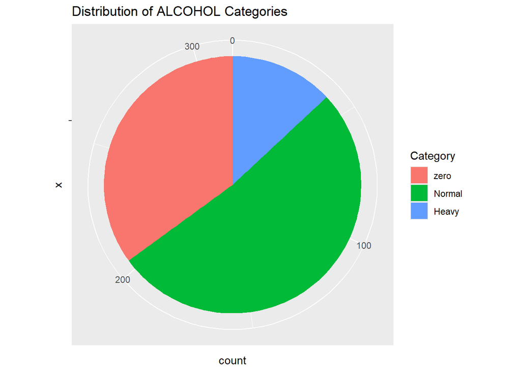

```r
# transform ALCOHOL to categorical data
data$ALCOHOL_Category <- cut(data$ALCOHOL,
                             breaks = c(-Inf, 0, 7, Inf),
                             labels = c("zero", "Normal", "Heavy"))

data$ALCOHOL_Category <- as.factor(data$ALCOHOL_Category)

# pie plot (ignore)
library(ggplot2)
ggplot(data, aes(x = "", fill = ALCOHOL_Category)) +
  geom_bar(width = 1, stat = "count") +
  coord_polar(theta = "y") +
  labs(title = "Distribution of ALCOHOL Categories", fill = "Category")
```

## 1-3. Data Splitting

```r
set.seed(206)
n <- nrow(data)  # sample size
train_size <- floor(0.8 * n)  # training data = 80%
train_indices <- sample(seq_len(n), size = train_size)

# construct training data and validation data
train_data <- data[train_indices, ]           # training data
validation_data <- data[-train_indices, ]     # validation data
```

Plot the distribution of the variables in the training set.

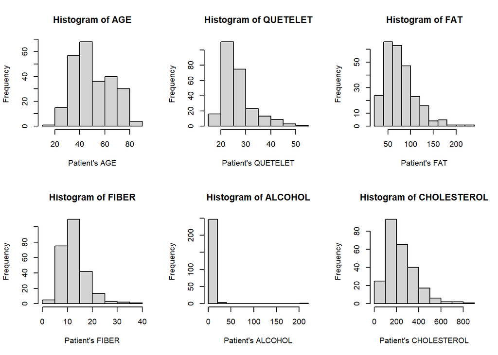

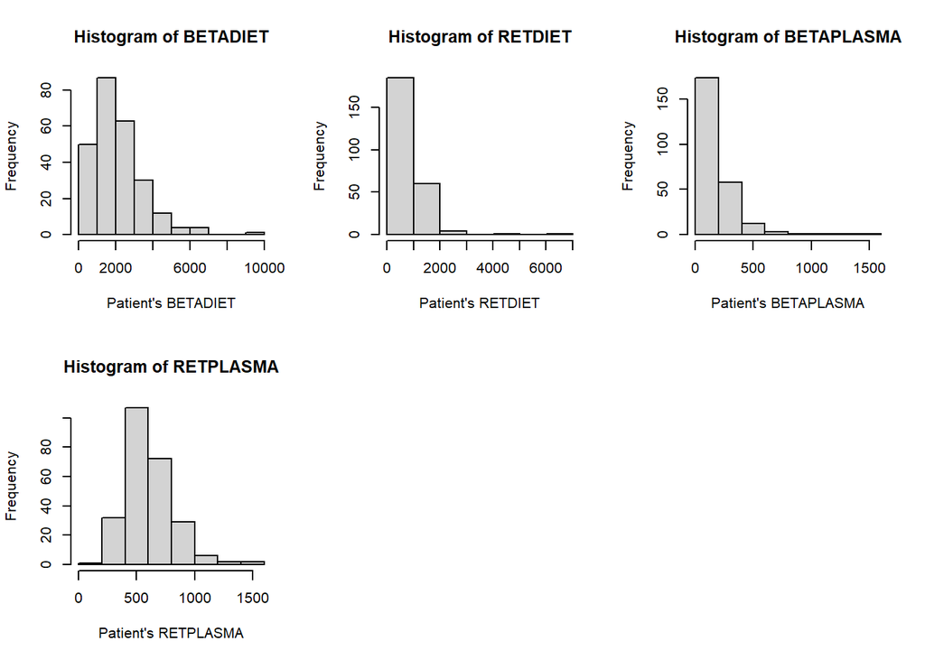

```r
# Draw plots to depict the distribution of each variable in the training set
par(mfrow = c(2, 3))
for(i in 4:13) {
hist(train_data[, i], main=paste("Histogram of", names(train_data)[i]), xlab = paste("Patient\'s", names(train_data)[i]))}
```

## 1-4. Preliminary regression

```r
# Preliminary regression (First-order model)
Model.1a = lm(BETAPLASMA ~ SEX + SMOKSTAT + VITUSE + AGE + QUETELET + FAT + FIBER + ALCOHOL_Category + CHOLESTEROL + BETADIET + RETDIET, data = train_data)
summary(Model.1a)
```

```
##
## Call:
## lm(formula = BETAPLASMA ~ SEX + SMOKSTAT + VITUSE + AGE + QUETELET +
##     FAT + FIBER + ALCOHOL_Category + CHOLESTEROL + BETADIET +
##     RETDIET, data = train_data)
##
## Residuals:
##     Min      1Q  Median      3Q     Max
## -223.92  -90.82  -28.67   43.24 1040.49
##
## Coefficients:
##                          Estimate Std. Error t value Pr(>|t|)
## (Intercept)            122.743337  75.583579   1.624  0.10572
## SEXMALE                -54.543859  34.189199  -1.595  0.11197
## SMOKSTATFORMER          37.646670  32.842382   1.146  0.25284
## SMOKSTATNEVER           60.065786  33.121602   1.813  0.07103 .
## VITUSENOT OFTEN         32.868913  27.069601   1.214  0.22587
## VITUSEOFTEN             54.195973  24.676862   2.196  0.02905 *
## AGE                      1.253167   0.770170   1.627  0.10504
## QUETELET                -5.494264   1.717337  -3.199  0.00157 **
## FAT                     -0.298188   0.431521  -0.691  0.49024
## FIBER                    6.486474   2.479855   2.616  0.00948 **
## ALCOHOL_CategoryNormal  19.307169  23.780920   0.812  0.41768
## ALCOHOL_CategoryHeavy   69.135268  35.732689   1.935  0.05421 .
## CHOLESTEROL             -0.109928   0.112577  -0.976  0.32983
## BETADIET                 0.015769   0.008668   1.819  0.07014 .
## RETDIET                 -0.002347   0.019036  -0.123  0.90197
## ---
## Signif. codes:  0 '***' 0.001 '**' 0.01 '*' 0.05 '.' 0.1 ' ' 1
##
## Residual standard error: 159.8 on 236 degrees of freedom
## Multiple R-squared:  0.2247, Adjusted R-squared:  0.1787
## F-statistic: 4.884 on 14 and 236 DF,  p-value: 6.302e-08
```

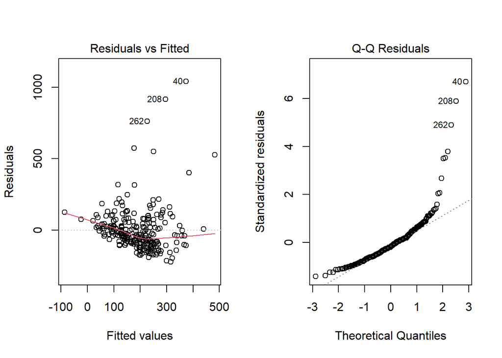

```r
par(mfrow = c(1, 2))
plot(Model.1a,which=1:2)
```

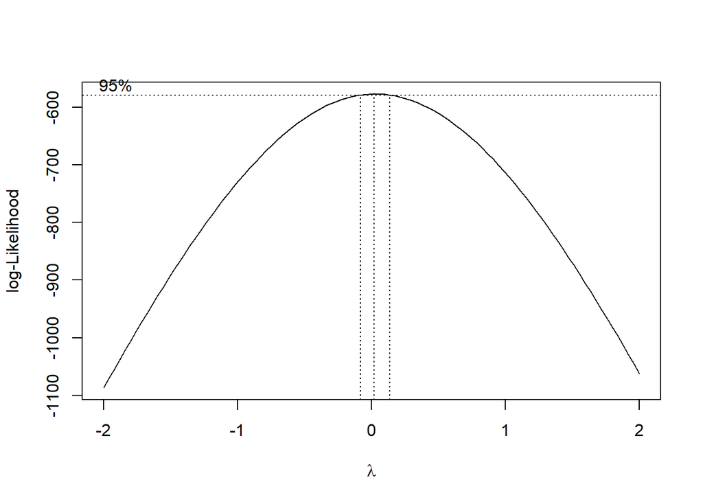

```r
par(mfrow = c(1, 1))
MASS::boxcox(Model.1a)
```

According to the output of BoxCox, we need a log transformation to the response variable $Y$, that is

$$Y_{new} = \log Y.$$

```r
# log transformation to the response variable Y
train_data$BETAPLASMA_log = log(train_data$BETAPLASMA)
validation_data$BETAPLASMA_log = log(validation_data$BETAPLASMA)

fit_test1 = lm(BETAPLASMA_log ~ SEX + SMOKSTAT + VITUSE + AGE + QUETELET + FAT + FIBER + ALCOHOL_Category + CHOLESTEROL + BETADIET + RETDIET, data = train_data)
summary(fit_test1)
```

```
##
## Call:
## lm(formula = BETAPLASMA_log ~ SEX + SMOKSTAT + VITUSE + AGE +
##     QUETELET + FAT + FIBER + ALCOHOL_Category + CHOLESTEROL +
##     BETADIET + RETDIET, data = train_data)
##
## Residuals:
##      Min       1Q   Median       3Q      Max
## -1.98214 -0.37035  0.01078  0.38906  1.82697
##
## Coefficients:
##                          Estimate Std. Error t value Pr(>|t|)
## (Intercept)             4.647e+00  3.068e-01  15.146  < 2e-16 ***
## SEXMALE                -2.370e-01  1.388e-01  -1.708  0.08894 .
## SMOKSTATFORMER          2.114e-01  1.333e-01   1.586  0.11414
## SMOKSTATNEVER           3.575e-01  1.344e-01   2.659  0.00837 **
## VITUSENOT OFTEN         2.215e-01  1.099e-01   2.016  0.04494 *
## VITUSEOFTEN             1.966e-01  1.002e-01   1.962  0.05089 .
## AGE                     8.134e-03  3.126e-03   2.602  0.00986 **
## QUETELET               -3.045e-02  6.971e-03  -4.368 1.88e-05 ***
## FAT                    -1.462e-03  1.752e-03  -0.835  0.40461
## FIBER                   2.357e-02  1.007e-02   2.341  0.02006 *
## ALCOHOL_CategoryNormal  1.896e-01  9.653e-02   1.964  0.05069 .
## ALCOHOL_CategoryHeavy   2.355e-01  1.450e-01   1.624  0.10580
## CHOLESTEROL            -4.914e-04  4.570e-04  -1.075  0.28328
## BETADIET                5.967e-05  3.518e-05   1.696  0.09123 .
## RETDIET                 3.668e-05  7.727e-05   0.475  0.63545
## ---
## Signif. codes:  0 '***' 0.001 '**' 0.01 '*' 0.05 '.' 0.1 ' ' 1
##
## Residual standard error: 0.6486 on 236 degrees of freedom
## Multiple R-squared:  0.2818, Adjusted R-squared:  0.2392
## F-statistic: 6.615 on 14 and 236 DF,  p-value: 2.773e-11
```

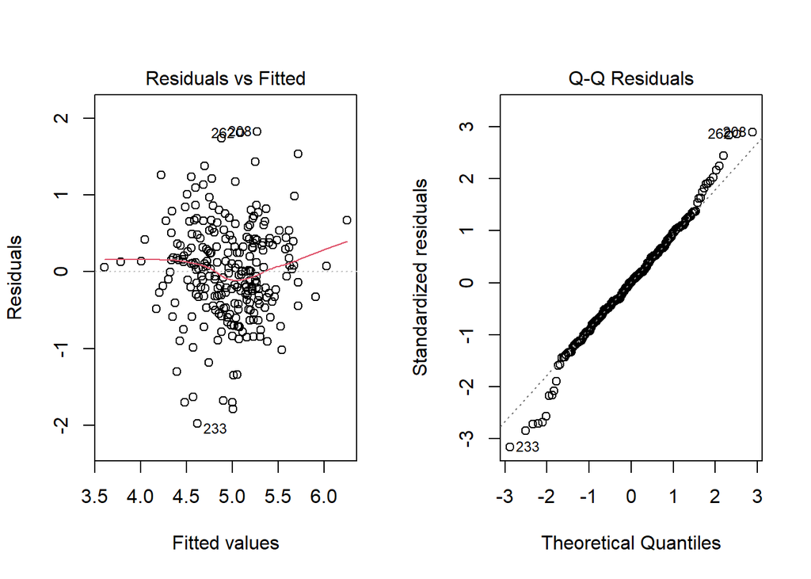

```r
par(mfrow = c(1, 2))
plot(fit_test1,which=1:2)
```

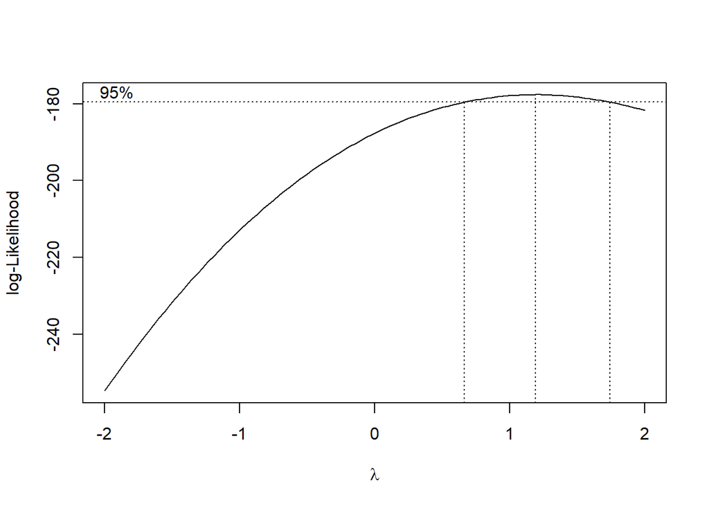

```r
par(mfrow = c(1, 1))
MASS::boxcox(fit_test1)
```

@@@ Based on the residuals vs fitted values plot, we need to add some interaction terms or quadratic terms in to the first-order model.

# 2. Model for BETAPLASMA

## 2-1. Model Construction for BETAPLASMA

Regressing the full model.

```r
# full model
fit_full_all = lm(BETAPLASMA_log ~ ((AGE + QUETELET + FAT + FIBER + CHOLESTEROL + BETADIET + RETDIET)^2 +
      I(AGE^2) + I(QUETELET^2) + I(FAT^2) + I(FIBER^2) + I(CHOLESTEROL^2) +
      I(BETADIET^2) + I(RETDIET^2)) *
      (ALCOHOL_Category + SEX + SMOKSTAT + VITUSE),
    data = train_data)

#summary(fit_full_all)

# full model without interaction terms (but we do not need the output)
fit_full = lm(BETAPLASMA_log ~ (AGE + QUETELET + FAT + FIBER + CHOLESTEROL + BETADIET + RETDIET +
      I(AGE^2) + I(QUETELET^2) + I(FAT^2) + I(FIBER^2) + I(CHOLESTEROL^2) +
      I(BETADIET^2) + I(RETDIET^2)) *
      (ALCOHOL_Category + SEX + SMOKSTAT + VITUSE),
    data = train_data)

#summary(fit_full)
```

## 2-2. Model search for BETAPLASMA

### 2-2-1. AIC

@@@ Since the number of X variables is quite large and variables containing interaction terms and quadratic terms may have multicollinearity, we should use forward stepwise procedures to search local best model.

```r
scope_formula <- as.formula(
  "~ ((AGE + QUETELET + FAT + FIBER + CHOLESTEROL + BETADIET + RETDIET)^2 +
      I(AGE^2) + I(QUETELET^2) + I(FAT^2) + I(FIBER^2) + I(CHOLESTEROL^2) +
      I(BETADIET^2) + I(RETDIET^2)) *
      (ALCOHOL_Category + SEX + SMOKSTAT + VITUSE)"
)

null_model <- lm(BETAPLASMA_log ~ 1, data = train_data)

# forward stepwise procedures
best_model_aic <- stepAIC(null_model,
                          scope = list(upper = scope_formula, lower = ~1),
                          direction = "both",  # forward stepwise procedures
                          k = 2,
                          trace = FALSE)

# checking the best model with criterion AIC
best_model_aic$anova
```

```
## Stepwise Model Path
## Analysis of Deviance Table
##
## Initial Model:
## BETAPLASMA_log ~ 1
##
## Final Model:
## BETAPLASMA_log ~ QUETELET + SMOKSTAT + I(FIBER^2) + I(CHOLESTEROL^2) +
##     BETADIET + VITUSE + AGE + I(AGE^2) + BETADIET:VITUSE + SMOKSTAT:I(CHOLESTEROL^2)
##
##
##                           Step Df  Deviance Resid. Df Resid. Dev       AIC
## 1                                                 250  138.23531 -147.7204
## 2                   + QUETELET  1 11.594326       249  126.64098 -167.7083
## 3                   + SMOKSTAT  2  9.987401       247  116.65358 -184.3273
## 4                 + I(FIBER^2)  1  6.032970       246  110.62061 -195.6560
## 5           + I(CHOLESTEROL^2)  1  2.821091       245  107.79952 -200.1401
## 6                   + BETADIET  1  1.949773       244  105.84974 -202.7215
## 7        + I(FIBER^2):SMOKSTAT  2  2.602386       242  103.24736 -204.9696
## 8                     + VITUSE  2  2.292022       240  100.95534 -206.6045
## 9            + BETADIET:VITUSE  2  2.862475       238   98.09286 -209.8241
## 10                       + AGE  1  1.731065       237   96.36180 -212.2931
## 11                  + I(AGE^2)  1  1.400456       236   94.96134 -213.9678
## 12 + I(CHOLESTEROL^2):SMOKSTAT  2  1.835116       234   93.12622 -214.8658
## 13       - SMOKSTAT:I(FIBER^2)  2  1.031402       236   94.15763 -216.1012
```

```r
summary(best_model_aic)
```

```
##
## Call:
## lm(formula = BETAPLASMA_log ~ QUETELET + SMOKSTAT + I(FIBER^2) +
##     I(CHOLESTEROL^2) + BETADIET + VITUSE + AGE + I(AGE^2) + BETADIET:VITUSE +
##     SMOKSTAT:I(CHOLESTEROL^2), data = train_data)
##
## Residuals:
##      Min       1Q   Median       3Q      Max
## -1.98683 -0.34205 -0.02058  0.40157  1.78562
##
## Coefficients:
##                                   Estimate Std. Error t value Pr(>|t|)
## (Intercept)                      4.468e+00  5.220e-01   8.561 1.46e-15 ***
## QUETELET                        -3.400e-02  6.670e-03  -5.098 7.04e-07 ***
## SMOKSTATFORMER                   3.236e-01  1.708e-01   1.895  0.05926 .
## SMOKSTATNEVER                    3.024e-01  1.645e-01   1.839  0.06723 .
## I(FIBER^2)                       6.558e-04  2.758e-04   2.378  0.01821 *
## I(CHOLESTEROL^2)                -1.567e-06  9.672e-07  -1.620  0.10663
## BETADIET                        -7.470e-05  6.352e-05  -1.176  0.24076
## VITUSENOT OFTEN                  7.688e-02  1.887e-01   0.407  0.68408
## VITUSEOFTEN                     -2.828e-01  1.850e-01  -1.529  0.12764
## AGE                              3.734e-02  1.926e-02   1.939  0.05372 .
## I(AGE^2)                        -2.903e-04  1.816e-04  -1.599  0.11113
## BETADIET:VITUSENOT OFTEN         1.105e-04  7.955e-05   1.389  0.16607
## BETADIET:VITUSEOFTEN             2.347e-04  7.673e-05   3.058  0.00248 **
## SMOKSTATFORMER:I(CHOLESTEROL^2) -1.091e-06  1.290e-06  -0.845  0.39871
## SMOKSTATNEVER:I(CHOLESTEROL^2)   1.412e-06  1.166e-06   1.211  0.22696
## ---
## Signif. codes:  0 '***' 0.001 '**' 0.01 '*' 0.05 '.' 0.1 ' ' 1
##
## Residual standard error: 0.6316 on 236 degrees of freedom
## Multiple R-squared:  0.3189, Adjusted R-squared:  0.2785
## F-statistic: 7.891 on 14 and 236 DF,  p-value: 1.101e-13
```

```r
vif_values <- vif(best_model_aic)
```

```
## there are higher-order terms (interactions) in this model
## consider setting type = 'predictor'; see ?vif
```

```r
print(vif_values)
```

```
##                                GVIF Df GVIF^(1/(2*Df))
## QUETELET                   1.070200  1        1.034505
## SMOKSTAT                   3.431841  2        1.361074
## I(FIBER^2)                 1.312275  1        1.145546
## I(CHOLESTEROL^2)           4.659576  1        2.158605
## BETADIET                   4.793410  1        2.189386
## VITUSE                    12.150622  2        1.867023
## AGE                       52.885934  1        7.272272
## I(AGE^2)                  52.669354  1        7.257366
## BETADIET:VITUSE           24.909010  2        2.234031
## SMOKSTAT:I(CHOLESTEROL^2)  9.269498  2        1.744874
```

@@@ Since there are some quadratic and interaction terms in the model, there may exist multicollinearity. Then, we can use standardization method to reduce the influence of multicollinearity.

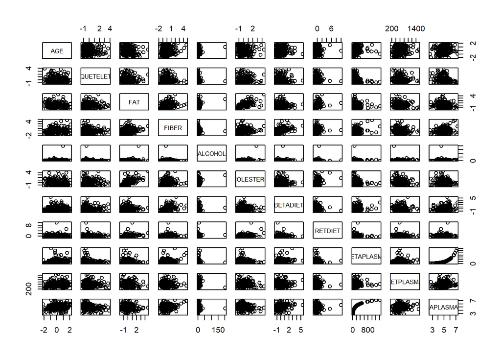

```r
# standardize train_data and validation_data
train_data2 <- train_data
validation_data2 = validation_data

train_data2$QUETELET <- scale(train_data$QUETELET)
train_data2$FIBER <- scale(train_data$FIBER)
train_data2$FAT <- scale(train_data$FAT)
train_data2$AGE <- scale(train_data$AGE)
train_data2$CHOLESTEROL <- scale(train_data$CHOLESTEROL)
train_data2$BETADIET <- scale(train_data$BETADIET)
train_data2$RETDIET <- scale(train_data$RETDIET)
# train_data2$BETAPLASMA_log <- scale(train_data$BETAPLASMA_log)


validation_data2$QUETELET <- scale(validation_data$QUETELET)
validation_data2$FIBER <- scale(validation_data$FIBER)
validation_data2$FAT <- scale(validation_data$FAT)
validation_data2$AGE <- scale(validation_data$AGE)
validation_data2$CHOLESTEROL <- scale(validation_data$CHOLESTEROL)
validation_data2$BETADIET <- scale(validation_data$BETADIET)
validation_data2$RETDIET <- scale(validation_data$RETDIET)
# validation_data2$BETAPLASMA_log <- scale(validation_data$BETAPLASMA_log)


par(mfrow = c(1, 1))
pairs(train_data2[,c(4:13,15)])
```

```r
cor(train_data2[,c(4:13,15)])
```

```
##                        AGE     QUETELET         FAT        FIBER      ALCOHOL
## AGE             1.00000000 -0.026501447 -0.15332750  0.064723748  0.041872068
## QUETELET       -0.02650145  1.000000000  0.04189803 -0.077254803 -0.084547236
## FAT            -0.15332750  0.041898030  1.00000000  0.288976882  0.203719086
## FIBER           0.06472375 -0.077254803  0.28897688  1.000000000 -0.009866584
## ALCOHOL         0.04187207 -0.084547236  0.20371909 -0.009866584  1.000000000
## CHOLESTEROL    -0.08570560  0.114144198  0.68125009  0.174583321  0.211456967
## BETADIET        0.09347254 -0.004247744  0.09473891  0.505262142  0.063591933
## RETDIET         0.02406129  0.030527025  0.38018813  0.218301442  0.055302051
## BETAPLASMA      0.12645772 -0.237613064 -0.09747653  0.261531157 -0.010759464
## RETPLASMA       0.20253685 -0.015358798 -0.06451467 -0.025504695  0.001705554
## BETAPLASMA_log  0.16401191 -0.289609810 -0.12811019  0.248133337 -0.015496564
##                CHOLESTEROL     BETADIET      RETDIET  BETAPLASMA    RETPLASMA
## AGE            -0.08570560  0.093472541  0.024061295  0.12645772  0.202536847
## QUETELET        0.11414420 -0.004247744  0.030527025 -0.23761306 -0.015358798
## FAT             0.68125009  0.094738907  0.380188131 -0.09747653 -0.064514666
## FIBER           0.17458332  0.505262142  0.218301442  0.26153116 -0.025504695
## ALCOHOL         0.21145697  0.063591933  0.055302051 -0.01075946  0.001705554
## CHOLESTEROL     1.00000000  0.095408733  0.412921067 -0.13817478 -0.032814039
## BETADIET        0.09540873  1.000000000  0.065503224  0.24343670  0.022975672
## RETDIET         0.41292107  0.065503224  1.000000000 -0.03072515 -0.029253250
## BETAPLASMA     -0.13817478  0.243436698 -0.030725150  1.00000000  0.078938300
## RETPLASMA      -0.03281404  0.022975672 -0.029253250  0.07893830  1.000000000
## BETAPLASMA_log -0.16513917  0.222864872 -0.001392479  0.83930817  0.133878263
##                BETAPLASMA_log
## AGE               0.164011906
## QUETELET         -0.289609810
## FAT              -0.128110186
## FIBER             0.248133337
## ALCOHOL          -0.015496564
## CHOLESTEROL      -0.165139169
## BETADIET          0.222864872
## RETDIET          -0.001392479
## BETAPLASMA        0.839308173
## RETPLASMA         0.133878263
## BETAPLASMA_log    1.000000000
```

```r
# regressing model in standardized data
best_model_aic_update_std <- lm(formula = BETAPLASMA_log ~ QUETELET + SMOKSTAT + I(FIBER^2) +
    I(CHOLESTEROL^2) + BETADIET + VITUSE + AGE + I(AGE^2) + BETADIET:VITUSE +
    SMOKSTAT:I(CHOLESTEROL^2), data = train_data2)

# checking
summary(best_model_aic_update_std)
```

```
##
## Call:
## lm(formula = BETAPLASMA_log ~ QUETELET + SMOKSTAT + I(FIBER^2) +
##     I(CHOLESTEROL^2) + BETADIET + VITUSE + AGE + I(AGE^2) + BETADIET:VITUSE +
##     SMOKSTAT:I(CHOLESTEROL^2), data = train_data2)
##
## Residuals:
##      Min       1Q   Median       3Q      Max
## -1.91079 -0.32391 -0.01893  0.43046  1.80652
##
## Coefficients:
##                                 Estimate Std. Error t value Pr(>|t|)
## (Intercept)                      4.54204    0.13878  32.728  < 2e-16 ***
## QUETELET                        -0.21634    0.04139  -5.227 3.79e-07 ***
## SMOKSTATFORMER                   0.30903    0.14565   2.122  0.03490 *
## SMOKSTATNEVER                    0.41446    0.14283   2.902  0.00406 **
## I(FIBER^2)                       0.04002    0.01939   2.064  0.04006 *
## I(CHOLESTEROL^2)                -0.04719    0.04078  -1.157  0.24838
## BETADIET                        -0.09740    0.08608  -1.132  0.25896
## VITUSENOT OFTEN                  0.30339    0.10807   2.807  0.00541 **
## VITUSEOFTEN                      0.23314    0.09856   2.365  0.01882 *
## AGE                              0.12128    0.04320   2.807  0.00541 **
## I(AGE^2)                        -0.07284    0.04175  -1.745  0.08236 .
## BETADIET:VITUSENOT OFTEN         0.17456    0.11030   1.583  0.11485
## BETADIET:VITUSEOFTEN             0.34117    0.10672   3.197  0.00158 **
## SMOKSTATFORMER:I(CHOLESTEROL^2) -0.04791    0.05629  -0.851  0.39551
## SMOKSTATNEVER:I(CHOLESTEROL^2)   0.02402    0.04873   0.493  0.62257
## ---
## Signif. codes:  0 '***' 0.001 '**' 0.01 '*' 0.05 '.' 0.1 ' ' 1
##
## Residual standard error: 0.6372 on 236 degrees of freedom
## Multiple R-squared:  0.3068, Adjusted R-squared:  0.2657
## F-statistic:  7.46 on 14 and 236 DF,  p-value: 7e-13
```

```r
print(vif_values)
```

```
##                                GVIF Df GVIF^(1/(2*Df))
## QUETELET                   1.070200  1        1.034505
## SMOKSTAT                   3.431841  2        1.361074
## I(FIBER^2)                 1.312275  1        1.145546
## I(CHOLESTEROL^2)           4.659576  1        2.158605
## BETADIET                   4.793410  1        2.189386
## VITUSE                    12.150622  2        1.867023
## AGE                       52.885934  1        7.272272
## I(AGE^2)                  52.669354  1        7.257366
## BETADIET:VITUSE           24.909010  2        2.234031
## SMOKSTAT:I(CHOLESTEROL^2)  9.269498  2        1.744874
```

```r
vif_values <- vif(best_model_aic_update_std)
```

```
## there are higher-order terms (interactions) in this model
## consider setting type = 'predictor'; see ?vif
```

```r
print(vif_values)
```

```
##                               GVIF Df GVIF^(1/(2*Df))
## QUETELET                  1.054717  1        1.026994
## SMOKSTAT                  1.750390  2        1.150227
## I(FIBER^2)                1.083225  1        1.040781
## I(CHOLESTEROL^2)          4.531612  1        2.128758
## BETADIET                  4.562043  1        2.135894
## VITUSE                    1.178650  2        1.041948
## AGE                       1.149105  1        1.071963
## I(AGE^2)                  1.098078  1        1.047892
## BETADIET:VITUSE           4.571636  2        1.462237
## SMOKSTAT:I(CHOLESTEROL^2) 5.783829  2        1.550793
```

According to the value of VIF, we can see there is a mild multicollinearity in the model. Then, we can use forward stepwise procedure again starting form “best_model_aic_update_std” model.

```r
Model.1f <- lm(formula = BETAPLASMA_log ~ QUETELET + SMOKSTAT + I(FIBER^2) +
    I(CHOLESTEROL^2) + BETADIET + VITUSE + AGE + I(AGE^2) + BETADIET:VITUSE, data = train_data2)
summary(Model.1f)
```

```
##
## Call:
## lm(formula = BETAPLASMA_log ~ QUETELET + SMOKSTAT + I(FIBER^2) +
##     I(CHOLESTEROL^2) + BETADIET + VITUSE + AGE + I(AGE^2) + BETADIET:VITUSE,
##     data = train_data2)
##
## Residuals:
##      Min       1Q   Median       3Q      Max
## -1.92346 -0.33239 -0.03294  0.42757  1.82176
##
## Coefficients:
##                          Estimate Std. Error t value Pr(>|t|)
## (Intercept)               4.54322    0.12813  35.457  < 2e-16 ***
## QUETELET                 -0.21556    0.04133  -5.215 3.98e-07 ***
## SMOKSTATFORMER            0.26977    0.13113   2.057 0.040743 *
## SMOKSTATNEVER             0.44052    0.12972   3.396 0.000802 ***
## I(FIBER^2)                0.04161    0.01936   2.149 0.032626 *
## I(CHOLESTEROL^2)         -0.04625    0.01961  -2.359 0.019130 *
## BETADIET                 -0.10127    0.08610  -1.176 0.240714
## VITUSENOT OFTEN           0.30638    0.10784   2.841 0.004885 **
## VITUSEOFTEN               0.23216    0.09826   2.363 0.018944 *
## AGE                       0.11925    0.04320   2.761 0.006219 **
## I(AGE^2)                 -0.07852    0.04161  -1.887 0.060337 .
## BETADIET:VITUSENOT OFTEN  0.18082    0.11026   1.640 0.102343
## BETADIET:VITUSEOFTEN      0.34350    0.10678   3.217 0.001476 **
## ---
## Signif. codes:  0 '***' 0.001 '**' 0.01 '*' 0.05 '.' 0.1 ' ' 1
##
## Residual standard error: 0.6376 on 238 degrees of freedom
## Multiple R-squared:    0.3,  Adjusted R-squared:  0.2647
## F-statistic: 8.498 on 12 and 238 DF,  p-value: 2.242e-13
```

```r
vif_values <- vif(Model.1f)
```

```
## there are higher-order terms (interactions) in this model
## consider setting type = 'predictor'; see ?vif
```

```r
print(vif_values)
```

```
##                      GVIF Df GVIF^(1/(2*Df))
## QUETELET         1.050315  1        1.024849
## SMOKSTAT         1.162387  2        1.038336
## I(FIBER^2)       1.078730  1        1.038619
## I(CHOLESTEROL^2) 1.045801  1        1.022644
## BETADIET         4.558072  1        2.134964
## VITUSE           1.167486  2        1.039472
## AGE              1.147411  1        1.071173
## I(AGE^2)         1.088810  1        1.043461
## BETADIET:VITUSE  4.559558  2        1.461271
```

After reoperating Stepwise, we do obtain a greater model.

**Final Model based on AIC:**

Then, we can use anova to check.

```r
# Test delete BETADIET:VITUSE
Model.1h = lm(BETAPLASMA_log ~ QUETELET + SMOKSTAT + I(FIBER^2) + I(CHOLESTEROL^2) + BETADIET + VITUSE + AGE + I(AGE^2), data = train_data2)
summary(Model.1h)
```

```
##
## Call:
## lm(formula = BETAPLASMA_log ~ QUETELET + SMOKSTAT + I(FIBER^2) +
##     I(CHOLESTEROL^2) + BETADIET + VITUSE + AGE + I(AGE^2), data = train_data2)
##
## Residuals:
##      Min       1Q   Median       3Q      Max
## -1.96004 -0.32312  0.02456  0.43631  1.85205
##
## Coefficients:
##                  Estimate Std. Error t value Pr(>|t|)
## (Intercept)       4.56436    0.13010  35.085  < 2e-16 ***
## QUETELET         -0.21795    0.04202  -5.187 4.55e-07 ***
## SMOKSTATFORMER    0.26318    0.13267   1.984 0.048435 *
## SMOKSTATNEVER     0.44080    0.13166   3.348 0.000945 ***
## I(FIBER^2)        0.04649    0.01964   2.367 0.018737 *
## I(CHOLESTEROL^2) -0.04044    0.01986  -2.036 0.042822 *
## BETADIET          0.10536    0.04277   2.463 0.014471 *
## VITUSENOT OFTEN   0.27541    0.10898   2.527 0.012144 *
## VITUSEOFTEN       0.21791    0.09930   2.195 0.029154 *
## AGE               0.10277    0.04345   2.365 0.018814 *
## I(AGE^2)         -0.07644    0.04228  -1.808 0.071828 .
## ---
## Signif. codes:  0 '***' 0.001 '**' 0.01 '*' 0.05 '.' 0.1 ' ' 1
##
## Residual standard error: 0.6489 on 240 degrees of freedom
## Multiple R-squared:  0.2688, Adjusted R-squared:  0.2384
## F-statistic: 8.824 on 10 and 240 DF,  p-value: 2.581e-12
```

```r
anova(Model.1h, Model.1f)
```

```
## Analysis of Variance Table
##
## Model 1: BETAPLASMA_log ~ QUETELET + SMOKSTAT + I(FIBER^2) + I(CHOLESTEROL^2) +
##     BETADIET + VITUSE + AGE + I(AGE^2)
## Model 2: BETAPLASMA_log ~ QUETELET + SMOKSTAT + I(FIBER^2) + I(CHOLESTEROL^2) +
##     BETADIET + VITUSE + AGE + I(AGE^2) + BETADIET:VITUSE
##   Res.Df    RSS Df Sum of Sq      F   Pr(>F)
## 1    240 101.07
## 2    238  96.77  2    4.3026 5.2909 0.005647 **
## ---
## Signif. codes:  0 '***' 0.001 '**' 0.01 '*' 0.05 '.' 0.1 ' ' 1
```

```r
# Test delete I(AGE^2)
Model.1g = lm(BETAPLASMA_log ~ QUETELET + SMOKSTAT + I(FIBER^2) + I(CHOLESTEROL^2) + BETADIET + VITUSE + AGE + BETADIET:VITUSE, data = train_data2)
summary(Model.1g)
```

```
##
## Call:
## lm(formula = BETAPLASMA_log ~ QUETELET + SMOKSTAT + I(FIBER^2) +
##     I(CHOLESTEROL^2) + BETADIET + VITUSE + AGE + BETADIET:VITUSE,
##     data = train_data2)
##
## Residuals:
##      Min       1Q   Median       3Q      Max
## -1.93498 -0.33491 -0.03799  0.42064  1.88354
##
## Coefficients:
##                          Estimate Std. Error t value Pr(>|t|)
## (Intercept)               4.47487    0.12357  36.214  < 2e-16 ***
## QUETELET                 -0.21170    0.04150  -5.101 6.88e-07 ***
## SMOKSTATFORMER            0.27737    0.13177   2.105 0.036334 *
## SMOKSTATNEVER             0.43440    0.13038   3.332 0.000999 ***
## I(FIBER^2)                0.03956    0.01943   2.036 0.042895 *
## I(CHOLESTEROL^2)         -0.04661    0.01971  -2.365 0.018830 *
## BETADIET                 -0.08483    0.08612  -0.985 0.325566
## VITUSENOT OFTEN           0.29269    0.10817   2.706 0.007302 **
## VITUSEOFTEN               0.22276    0.09865   2.258 0.024851 *
## AGE                       0.10096    0.04232   2.386 0.017833 *
## BETADIET:VITUSENOT OFTEN  0.16958    0.11069   1.532 0.126827
## BETADIET:VITUSEOFTEN      0.33884    0.10732   3.157 0.001798 **
## ---
## Signif. codes:  0 '***' 0.001 '**' 0.01 '*' 0.05 '.' 0.1 ' ' 1
##
## Residual standard error: 0.6411 on 239 degrees of freedom
## Multiple R-squared:  0.2895, Adjusted R-squared:  0.2568
## F-statistic: 8.852 on 11 and 239 DF,  p-value: 3.587e-13
```

```r
anova(Model.1g, Model.1f)
```

```
## Analysis of Variance Table
##
## Model 1: BETAPLASMA_log ~ QUETELET + SMOKSTAT + I(FIBER^2) + I(CHOLESTEROL^2) +
##     BETADIET + VITUSE + AGE + BETADIET:VITUSE
## Model 2: BETAPLASMA_log ~ QUETELET + SMOKSTAT + I(FIBER^2) + I(CHOLESTEROL^2) +
##     BETADIET + VITUSE + AGE + I(AGE^2) + BETADIET:VITUSE
##   Res.Df    RSS Df Sum of Sq      F  Pr(>F)
## 1    239 98.218
## 2    238 96.770  1    1.4483 3.5619 0.06034 .
## ---
## Signif. codes:  0 '***' 0.001 '**' 0.01 '*' 0.05 '.' 0.1 ' ' 1
```

According to the outputs of anova, we should delete I(AGE^2) manually and retain BETADIET:VITUSE. Therefore, we can obtain the final model.

```r
final_model_aic = Model.1g
summary(Model.1g)
```

```
##
## Call:
## lm(formula = BETAPLASMA_log ~ QUETELET + SMOKSTAT + I(FIBER^2) +
##     I(CHOLESTEROL^2) + BETADIET + VITUSE + AGE + BETADIET:VITUSE,
##     data = train_data2)
##
## Residuals:
##      Min       1Q   Median       3Q      Max
## -1.93498 -0.33491 -0.03799  0.42064  1.88354
##
## Coefficients:
##                          Estimate Std. Error t value Pr(>|t|)
## (Intercept)               4.47487    0.12357  36.214  < 2e-16 ***
## QUETELET                 -0.21170    0.04150  -5.101 6.88e-07 ***
## SMOKSTATFORMER            0.27737    0.13177   2.105 0.036334 *
## SMOKSTATNEVER             0.43440    0.13038   3.332 0.000999 ***
## I(FIBER^2)                0.03956    0.01943   2.036 0.042895 *
## I(CHOLESTEROL^2)         -0.04661    0.01971  -2.365 0.018830 *
## BETADIET                 -0.08483    0.08612  -0.985 0.325566
## VITUSENOT OFTEN           0.29269    0.10817   2.706 0.007302 **
## VITUSEOFTEN               0.22276    0.09865   2.258 0.024851 *
## AGE                       0.10096    0.04232   2.386 0.017833 *
## BETADIET:VITUSENOT OFTEN  0.16958    0.11069   1.532 0.126827
## BETADIET:VITUSEOFTEN      0.33884    0.10732   3.157 0.001798 **
## ---
## Signif. codes:  0 '***' 0.001 '**' 0.01 '*' 0.05 '.' 0.1 ' ' 1
##
## Residual standard error: 0.6411 on 239 degrees of freedom
## Multiple R-squared:  0.2895, Adjusted R-squared:  0.2568
## F-statistic: 8.852 on 11 and 239 DF,  p-value: 3.587e-13
```

```r
# checking model
vif_values <- vif(Model.1g)
```

```
## there are higher-order terms (interactions) in this model
## consider setting type = 'predictor'; see ?vif
```

```r
print(vif_values)
```

```
##                      GVIF Df GVIF^(1/(2*Df))
## QUETELET         1.047741  1        1.023592
## SMOKSTAT         1.154678  2        1.036609
## I(FIBER^2)       1.075328  1        1.036980
## I(CHOLESTEROL^2) 1.045701  1        1.022595
## BETADIET         4.511466  1        2.124021
## VITUSE           1.161678  2        1.038177
## AGE              1.089651  1        1.043864
## BETADIET:VITUSE  4.545404  2        1.460135
```

According to the Hierarchical principle, we can try to add the corresponding lower-order terms with respect to those higher-order terms into the model.

### 2-2-2. BIC

Similarly, we can use BIC to search the “best” model.

```r
scope_formula <- as.formula(
  "~ ((AGE + QUETELET + FAT + FIBER + CHOLESTEROL + BETADIET + RETDIET)^2 +
      I(AGE^2) + I(QUETELET^2) + I(FAT^2) + I(FIBER^2) + I(CHOLESTEROL^2) +
      I(BETADIET^2) + I(RETDIET^2)) *
      (ALCOHOL_Category + SEX + SMOKSTAT + VITUSE)"
)

null_model <- lm(BETAPLASMA_log ~ 1, data = train_data2)

# forward stepwise procedures
best_model_bic <- stepAIC(null_model,
                          scope = list(upper = scope_formula, lower = ~1),
                          direction = "both",  # forward stepwise procedures
                          k = log(nrow(train_data2)),
                          trace = FALSE)

# checking the best model with criterion BIC
best_model_bic$anova
```

```
## Stepwise Model Path
## Analysis of Deviance Table
##
## Initial Model:
## BETAPLASMA_log ~ 1
##
## Final Model:
## BETAPLASMA_log ~ QUETELET + SMOKSTAT + BETADIET + I(FIBER^2)
##
##
##           Step Df  Deviance Resid. Df Resid. Dev       AIC
## 1                                 250   138.2353 -144.1949
## 2   + QUETELET  1 11.594326       249   126.6410 -160.6574
## 3   + SMOKSTAT  2  9.987401       247   116.6536 -170.2255
## 4   + BETADIET  1  5.326828       246   111.3268 -176.4316
## 5 + I(FIBER^2)  1  2.752400       245   108.5744 -177.1897
```

```r
summary(best_model_bic)
```

```
##
## Call:
## lm(formula = BETAPLASMA_log ~ QUETELET + SMOKSTAT + BETADIET +
##     I(FIBER^2), data = train_data2)
##
## Residuals:
##      Min       1Q   Median       3Q      Max
## -2.14500 -0.39675 -0.01481  0.46977  1.95526
##
## Coefficients:
##                Estimate Std. Error t value Pr(>|t|)
## (Intercept)     4.51447    0.11537  39.131  < 2e-16 ***
## QUETELET       -0.22687    0.04271  -5.312 2.43e-07 ***
## SMOKSTATFORMER  0.36092    0.13292   2.715  0.00709 **
## SMOKSTATNEVER   0.54527    0.12960   4.207 3.63e-05 ***
## BETADIET        0.12798    0.04324   2.960  0.00338 **
## I(FIBER^2)      0.04969    0.01994   2.492  0.01336 *
## ---
## Signif. codes:  0 '***' 0.001 '**' 0.01 '*' 0.05 '.' 0.1 ' ' 1
##
## Residual standard error: 0.6657 on 245 degrees of freedom
## Multiple R-squared:  0.2146, Adjusted R-squared:  0.1985
## F-statistic: 13.39 on 5 and 245 DF,  p-value: 1.522e-11
```

```r
# Compairing final model selected by AIC and BIC
anova(best_model_bic, Model.1g)
```

```
## Analysis of Variance Table
##
## Model 1: BETAPLASMA_log ~ QUETELET + SMOKSTAT + BETADIET + I(FIBER^2)
## Model 2: BETAPLASMA_log ~ QUETELET + SMOKSTAT + I(FIBER^2) + I(CHOLESTEROL^2) +
##     BETADIET + VITUSE + AGE + BETADIET:VITUSE
##   Res.Df     RSS Df Sum of Sq      F    Pr(>F)
## 1    245 108.574
## 2    239  98.218  6    10.356 4.2001 0.0004887 ***
## ---
## Signif. codes:  0 '***' 0.001 '**' 0.01 '*' 0.05 '.' 0.1 ' ' 1
```

Since BIC imposes a stricter penalty on model complexity, the model selected by BIC tends to include fewer X variables. However, using BIC to searching model resulting in a significant decrease in adjusted R^2, making us more inclined to choose the model selected by AIC. Furthermore, the model selected by BIC can, to some extent, be considered a sub-model of the final model selected by AIC, which provides partial support for the model chosen by AIC.

Besides, according to the anova result, we can see adding extra variables is significant, so we should choose model searched by AIC.

## 2-3. Model Validation for BETAPLASMA

The final model is BETAPLASMA_log ~ QUETELET + SMOKSTAT + I(FIBER^2) + I(CHOLESTEROL^2) + BETADIET + VITUSE + AGE + BETADIET:VITUSE.

### 2-3-1. External Validation

```r
# Mean Squared Prediction Error (MSPE)
actual_values <- validation_data2$BETAPLASMA_log
predicted_values <- predict(Model.1g, newdata = validation_data2)
MSPE = sum((actual_values - predicted_values)^2) / nrow(validation_data2)
MSPE
```

```
## [1] 0.499051
```

```r
SSE = sum((Model.1g$residuals)^2)
SSE/nrow(train_data2)
```

```
## [1] 0.3913071
```

Since $MSPE$ is not much larger than $\frac{SSE}{n}$, this indicates no severe over-fitting by the model. Besides, this model has a certain degree of predictive power.

### 2-3-2. Internal Validation

```r
# Mallows' Cp
p = length(coef(Model.1g))
sigma2 = summary(Model.1g)$sigma^2
Cp = SSE/sigma2 - (nrow(train_data2) - 2 * p)
Cp
```

```
## [1] 12
```

```r
p
```

```
## [1] 12
```

```r
# PRESSp
residuals <- resid(Model.1g)
h <- hatvalues(Model.1g)
PRESSp <- sum((residuals / (1 - h))^2)
PRESSp
```

```
## [1] 108.176
```

```r
SSE
```

```
## [1] 98.21809
```

We have
$$C_p = 12, p = 12\quad and \quad
Press_p = 108.176, SSE_p = 98.21809.$$
Since $C_p$ is not much larger than $p$ and $Press_p$ is not much larger than $SSE_p$, we can say there is no severe over-fitting and no substantial model bias.

### 2-3-3. Regression on the entire data

```r
data_entire2 = rbind(train_data2,validation_data2)
Model.1entire = lm(BETAPLASMA_log ~ QUETELET + SMOKSTAT + I(FIBER^2) + I(CHOLESTEROL^2) + BETADIET + VITUSE + AGE + BETADIET:VITUSE, data = data_entire2)
summary(Model.1entire)
```

```
##
## Call:
## lm(formula = BETAPLASMA_log ~ QUETELET + SMOKSTAT + I(FIBER^2) +
##     I(CHOLESTEROL^2) + BETADIET + VITUSE + AGE + BETADIET:VITUSE,
##     data = data_entire2)
##
## Residuals:
##      Min       1Q   Median       3Q      Max
## -1.98862 -0.33943 -0.01783  0.41763  1.83580
##
## Coefficients:
##                          Estimate Std. Error t value Pr(>|t|)
## (Intercept)               4.48067    0.11418  39.243  < 2e-16 ***
## QUETELET                 -0.19970    0.03779  -5.285 2.42e-07 ***
## SMOKSTATFORMER            0.24789    0.12042   2.058  0.04040 *
## SMOKSTATNEVER             0.37243    0.11740   3.172  0.00167 **
## I(FIBER^2)                0.04280    0.01813   2.361  0.01885 *
## I(CHOLESTEROL^2)         -0.05231    0.01877  -2.787  0.00565 **
## BETADIET                 -0.05739    0.07274  -0.789  0.43077
## VITUSENOT OFTEN           0.30177    0.09732   3.101  0.00211 **
## VITUSEOFTEN               0.31117    0.08857   3.513  0.00051 ***
## AGE                       0.08067    0.03827   2.108  0.03589 *
## BETADIET:VITUSENOT OFTEN  0.14502    0.09844   1.473  0.14173
## BETADIET:VITUSEOFTEN      0.27925    0.09290   3.006  0.00287 **
## ---
## Signif. codes:  0 '***' 0.001 '**' 0.01 '*' 0.05 '.' 0.1 ' ' 1
##
## Residual standard error: 0.6529 on 302 degrees of freedom
## Multiple R-squared:  0.2643, Adjusted R-squared:  0.2375
## F-statistic: 9.863 on 11 and 302 DF,  p-value: 2.688e-15
```

## 2-4. Model Explanation for BETAPLASMA

**BETAPLASMA_log ~ QUETELET + SMOKSTAT + I(FIBER^2) + I(CHOLESTEROL^2) + BETADIET + VITUSE + AGE + BETADIET:VITUSE**

The function is
$$Y_i = 4.47487 -
0.21170*X_{QUETELET,i} + 0.27737*D_{SMOKSTAT,FORMER} +0.4344 *
D_{SMOKSTAT,NEVER} - 0.08483 * X_{BETADIET,i} + 0.10096 * X_{AGE,i}$$
$$+0.03956 * X^2_{FIBER,i} -0.04661
* X^2_{CHOLESTEROL,i} + 0.29269 * D_{VITUSE,NOTOFTEN} + 0.22276 *
D_{VITUSE,OFTEN}$$
$$+0.16958 *
X_{BETADIET,i} * D_{VITUSE,NOTOFTEN} + 0.33884 * X_{BETADIET,i} *
D_{VITUSE,OFTEN}$$

1. Scatter plots show the relationship between continuous and dependent variables

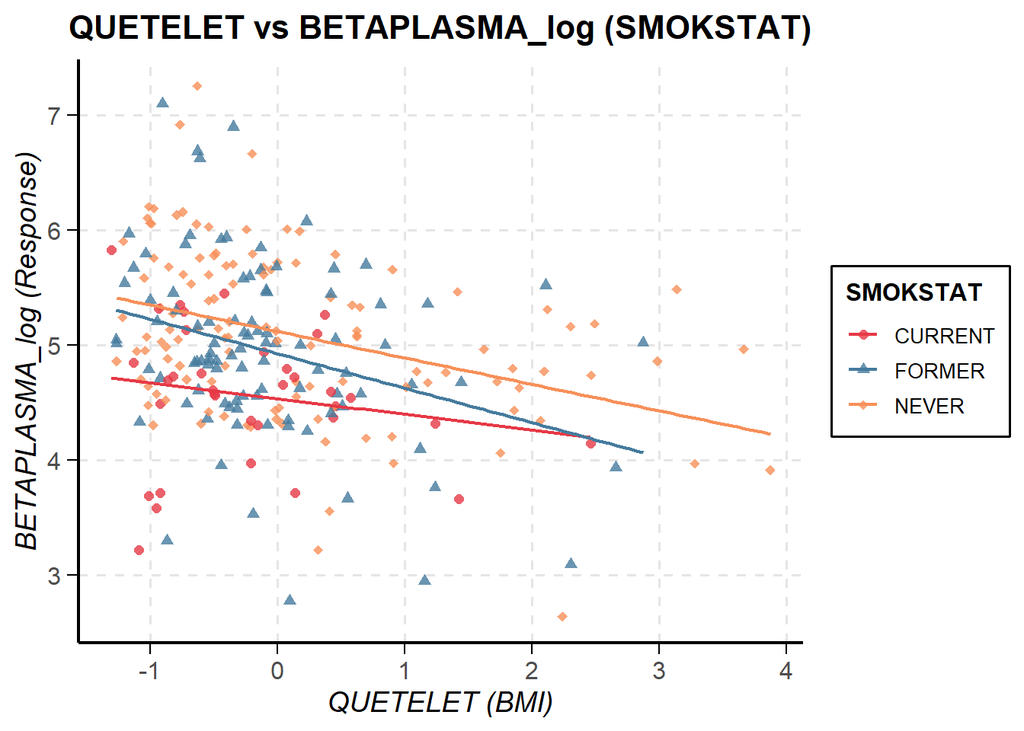

```r
library(ggplot2)


custom_theme <- theme_minimal(base_size = 14) +
  theme(
    panel.grid.major = element_line(color = "gray90", linetype = "dashed"),
    panel.grid.minor = element_blank(),
    axis.line = element_line(color = "black", size = 0.8),
    axis.ticks = element_line(color = "black", size = 0.5),
    axis.ticks.length = unit(0.2, "cm"),
    plot.title = element_text(size = 16, face = "bold", hjust = 0.5),
    axis.title.x = element_text(size = 14, face = "italic"),
    axis.title.y = element_text(size = 14, face = "italic"),
    axis.text = element_text(size = 12),
    legend.position = "right",
    legend.justification = "center",
    legend.direction = "vertical",
    legend.background = element_rect(fill = "white", color = "black"),
    legend.title = element_text(size = 12, face = "bold"),
    legend.text = element_text(size = 10)
  )
ggplot(train_data2, aes(x = QUETELET, y = BETAPLASMA_log, color = SMOKSTAT, shape = SMOKSTAT)) +
  geom_point(size = 2, alpha = 0.8) +
  geom_smooth(method = "lm", se = FALSE, size = 0.8) +
  scale_color_manual(values = c("#E63946", "#457B9D", "#f79059")) +
  scale_shape_manual(values = c(16, 17, 18)) +
  labs(title = "QUETELET vs BETAPLASMA_log (SMOKSTAT)",
       x = "QUETELET (BMI)",
       y = "BETAPLASMA_log (Response)") +
  custom_theme
```

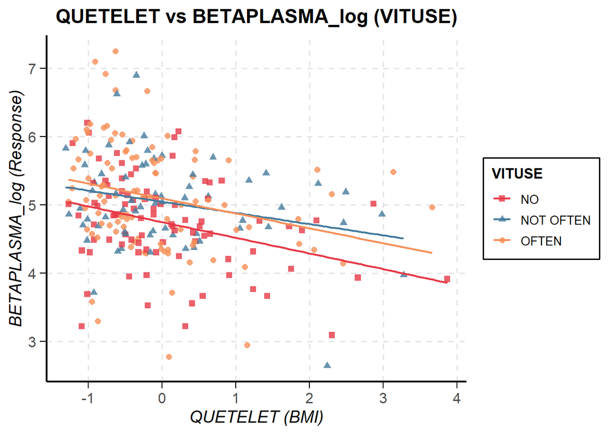

```r
ggplot(train_data2, aes(x = QUETELET, y = BETAPLASMA_log, color = VITUSE, shape = VITUSE)) +
  geom_point(size = 2, alpha = 0.8) +
  geom_smooth(method = "lm", se = FALSE, size = 0.8) +
  scale_color_manual(values = c("#E63946", "#457B9D", "#f79059")) +
  scale_shape_manual(values = c(15, 17, 19)) +
  labs(title = "QUETELET vs BETAPLASMA_log (VITUSE)",
       x = "QUETELET (BMI)",
       y = "BETAPLASMA_log (Response)") +
  custom_theme
```

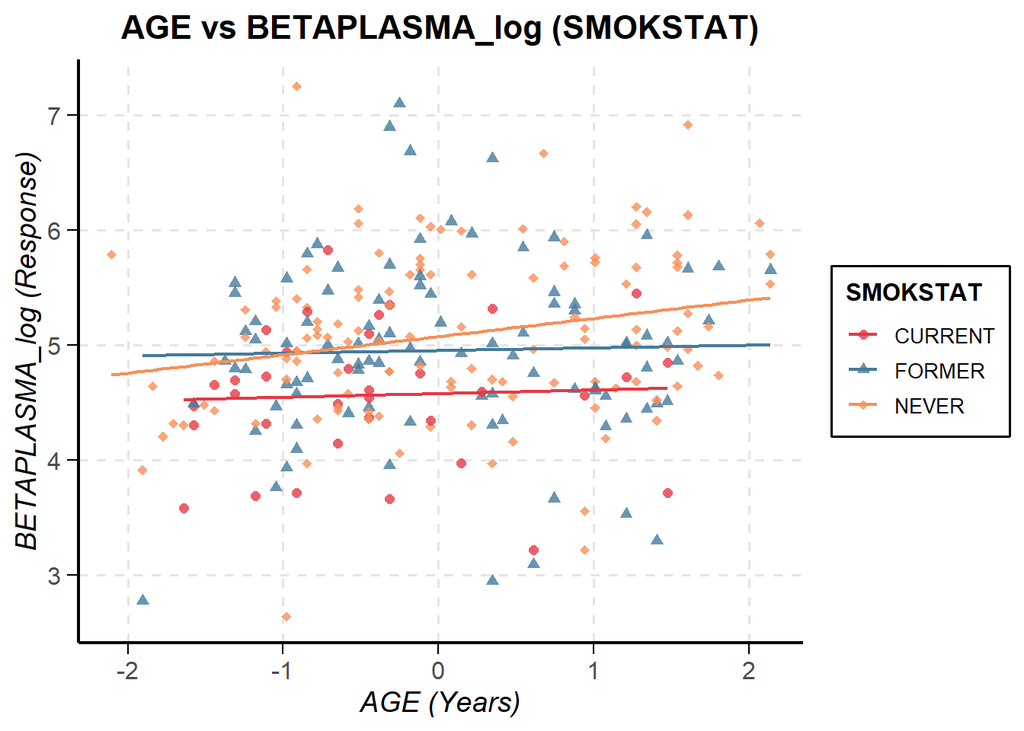

```r
ggplot(train_data2, aes(x = AGE, y = BETAPLASMA_log, color = SMOKSTAT, shape = SMOKSTAT)) +
  geom_point(size = 2, alpha = 0.8) +
  geom_smooth(method = "lm", se = FALSE, size = 0.8) +
  scale_color_manual(values = c("#E63946", "#457B9D", "#f79059")) +
  scale_shape_manual(values = c(16, 17, 18)) +
  labs(title = "AGE vs BETAPLASMA_log (SMOKSTAT)",
       x = "AGE (Years)",
       y = "BETAPLASMA_log (Response)") +
  custom_theme
```

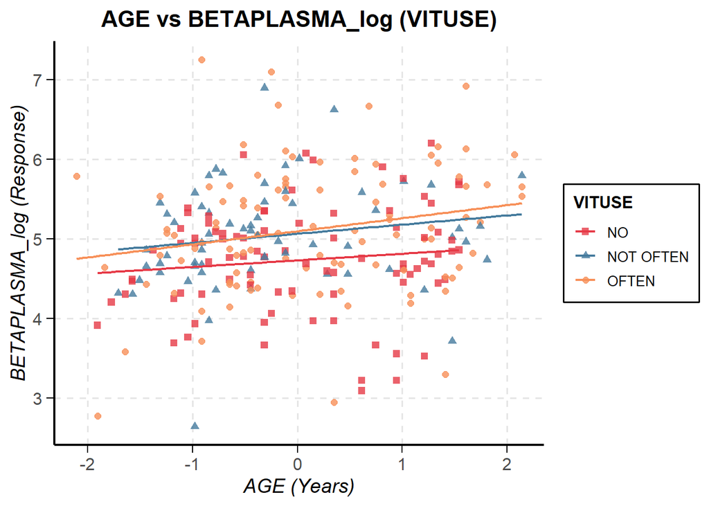

```r
ggplot(train_data2, aes(x = AGE, y = BETAPLASMA_log, color = VITUSE, shape = VITUSE)) +
  geom_point(size = 2, alpha = 0.8) +
  geom_smooth(method = "lm", se = FALSE, size = 0.8) +
  scale_color_manual(values = c("#E63946", "#457B9D", "#f79059")) +
  scale_shape_manual(values = c(15, 17, 19)) +
  labs(title = "AGE vs BETAPLASMA_log (VITUSE)",
       x = "AGE (Years)",
       y = "BETAPLASMA_log (Response)") +
  custom_theme
```

2. Visualization of quadratic terms of nonlinear variables such as FIBER and CHOLESTEROL

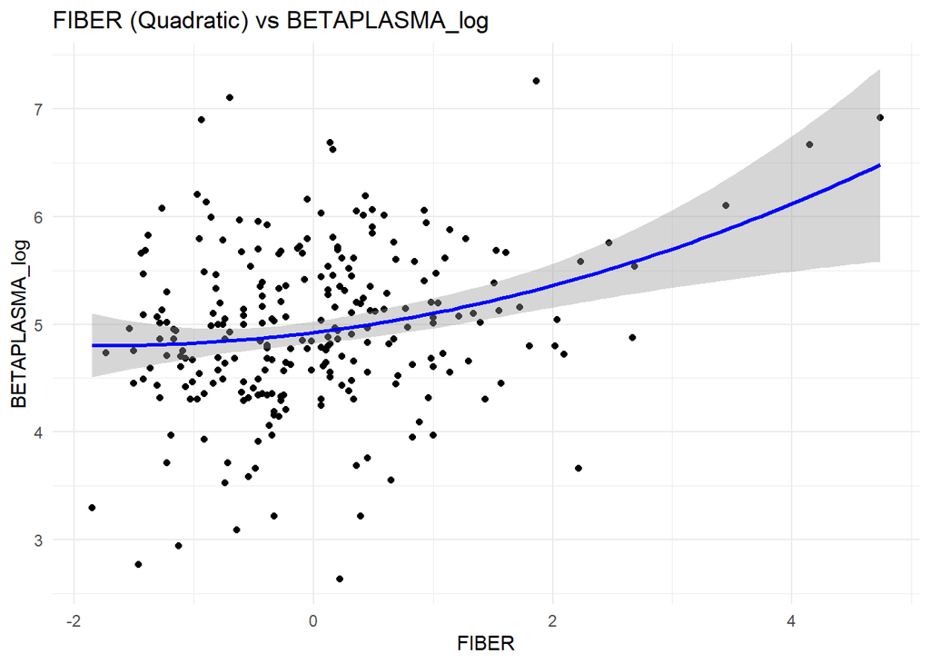

```r
ggplot(train_data2, aes(x = FIBER, y = BETAPLASMA_log)) +
  geom_point() +
  stat_smooth(method = "lm", formula = y ~ poly(x, 2), color = "blue") +  # 二次拟合曲线
  labs(title = "FIBER (Quadratic) vs BETAPLASMA_log", x = "FIBER", y = "BETAPLASMA_log") +
  theme_minimal()
```

3. Visualization of categorical variables and interaction terms

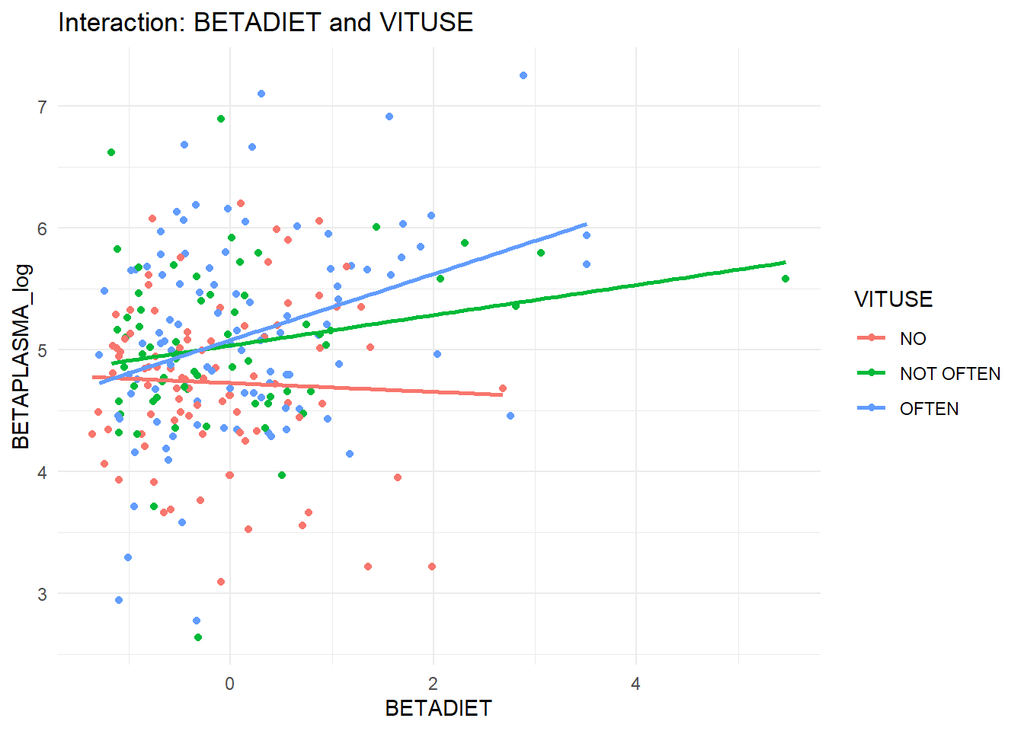

```r
ggplot(train_data2, aes(x = BETADIET, y = BETAPLASMA_log, color = VITUSE)) +
  geom_point() +
  geom_smooth(method = "lm", se = FALSE) +  # 添加回归线
  labs(title = "Interaction: BETADIET and VITUSE", x = "BETADIET", y = "BETAPLASMA_log") +
  theme_minimal()
```

4. Box plot of categorical variables

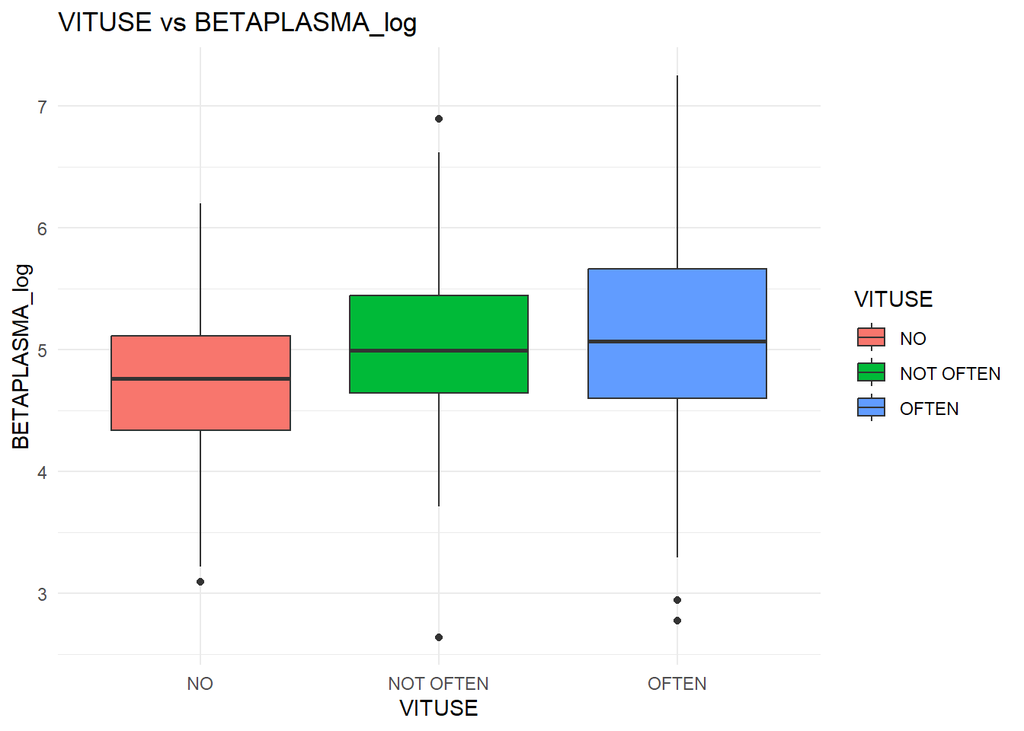

```r
ggplot(train_data2, aes(x = VITUSE, y = BETAPLASMA_log, fill = VITUSE)) +
  geom_boxplot() +
  labs(title = "VITUSE vs BETAPLASMA_log", x = "VITUSE", y = "BETAPLASMA_log") +
  theme_minimal()
```

# 3. Model for RETPLASMA

## 3-1. Model Construction for RETPLASMA

```r
# Preliminary regression (First-order model)
fit_pre2 = lm(RETPLASMA ~ SEX + SMOKSTAT + VITUSE + AGE + QUETELET + FAT + FIBER + ALCOHOL_Category + CHOLESTEROL + BETADIET + RETDIET, data = train_data2)
summary(fit_pre2)
```

```
##
## Call:
## lm(formula = RETPLASMA ~ SEX + SMOKSTAT + VITUSE + AGE + QUETELET +
##     FAT + FIBER + ALCOHOL_Category + CHOLESTEROL + BETADIET +
##     RETDIET, data = train_data2)
##
## Residuals:
##     Min      1Q  Median      3Q     Max
## -462.56 -124.24  -35.17  105.57  926.41
##
## Coefficients:
##                        Estimate Std. Error t value Pr(>|t|)
## (Intercept)            509.9710    42.2158  12.080  < 2e-16 ***
## SEXMALE                 68.7047    42.5964   1.613 0.108098
## SMOKSTATFORMER          37.4751    40.9184   0.916 0.360681
## SMOKSTATNEVER            2.2187    41.2663   0.054 0.957167
## VITUSENOT OFTEN         38.3699    33.7261   1.138 0.256403
## VITUSEOFTEN             54.9380    30.7450   1.787 0.075238 .
## AGE                     36.0878    14.4733   2.493 0.013339 *
## QUETELET                 8.1603    13.2570   0.616 0.538789
## FAT                    -13.7107    18.2974  -0.749 0.454409
## FIBER                  -11.0509    15.8013  -0.699 0.485012
## ALCOHOL_CategoryNormal  39.0997    29.6287   1.320 0.188229
## ALCOHOL_CategoryHeavy  149.4130    44.5194   3.356 0.000921 ***
## CHOLESTEROL             -5.7438    18.2014  -0.316 0.752610
## BETADIET                 0.8201    14.8699   0.055 0.956066
## RETDIET                  1.8409    14.3495   0.128 0.898027
## ---
## Signif. codes:  0 '***' 0.001 '**' 0.01 '*' 0.05 '.' 0.1 ' ' 1
##
## Residual standard error: 199.1 on 236 degrees of freedom
## Multiple R-squared:  0.1257, Adjusted R-squared:  0.07381
## F-statistic: 2.423 on 14 and 236 DF,  p-value: 0.003411
```

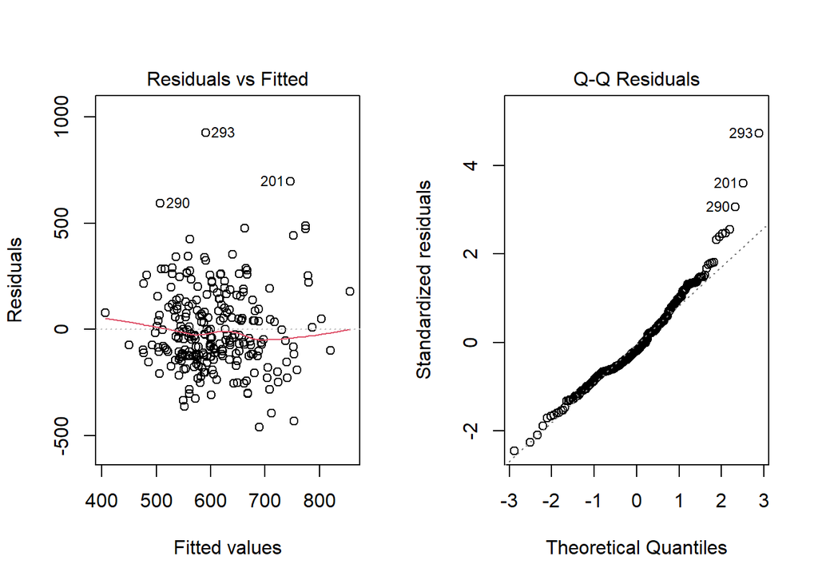

```r
par(mfrow = c(1, 2))
plot(fit_pre2,which=1:2)
```

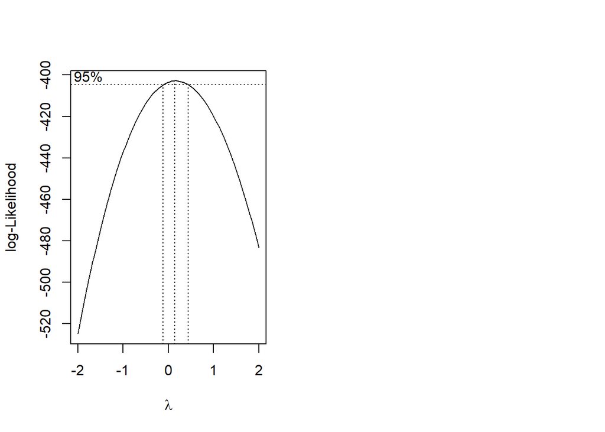

```r
MASS::boxcox(fit_pre2)
```

According to the output of BoxCox, we need a log transformation to the response variable $Y$, that is

$$Y_{new} = \log Y.$$

```r
# log transformation to the response variable Y
train_data$RETPLASMA_log = log(train_data$RETPLASMA)
validation_data$RETPLASMA_log = log(validation_data$RETPLASMA)

train_data2$RETPLASMA_log <- train_data$RETPLASMA_log
validation_data2$RETPLASMA_log <- validation_data$RETPLASMA_log

fit_test2 = lm(RETPLASMA_log ~ SEX + SMOKSTAT + VITUSE + AGE + QUETELET + FAT + FIBER + ALCOHOL_Category + CHOLESTEROL + BETADIET + RETDIET, data = train_data2)
summary(fit_test2)
```

```
##
## Call:
## lm(formula = RETPLASMA_log ~ SEX + SMOKSTAT + VITUSE + AGE +
##     QUETELET + FAT + FIBER + ALCOHOL_Category + CHOLESTEROL +
##     BETADIET + RETDIET, data = train_data2)
##
## Residuals:
##      Min       1Q   Median       3Q      Max
## -1.01877 -0.19449 -0.01312  0.21989  0.99859
##
## Coefficients:
##                          Estimate Std. Error t value Pr(>|t|)
## (Intercept)             6.1903531  0.0688750  89.878  < 2e-16 ***
## SEXMALE                 0.0744721  0.0694960   1.072  0.28499
## SMOKSTATFORMER          0.0740665  0.0667583   1.109  0.26836
## SMOKSTATNEVER           0.0128945  0.0673259   0.192  0.84828
## VITUSENOT OFTEN         0.0627222  0.0550241   1.140  0.25548
## VITUSEOFTEN             0.0726655  0.0501604   1.449  0.14876
## AGE                     0.0658458  0.0236132   2.789  0.00573 **
## QUETELET                0.0034964  0.0216288   0.162  0.87172
## FAT                    -0.0338810  0.0298522  -1.135  0.25754
## FIBER                  -0.0151300  0.0257798  -0.587  0.55783
## ALCOHOL_CategoryNormal  0.0803308  0.0483392   1.662  0.09788 .
## ALCOHOL_CategoryHeavy   0.2283846  0.0726334   3.144  0.00188 **
## CHOLESTEROL             0.0001731  0.0296955   0.006  0.99535
## BETADIET               -0.0082908  0.0242602  -0.342  0.73285
## RETDIET                 0.0037422  0.0234113   0.160  0.87314
## ---
## Signif. codes:  0 '***' 0.001 '**' 0.01 '*' 0.05 '.' 0.1 ' ' 1
##
## Residual standard error: 0.3248 on 236 degrees of freedom
## Multiple R-squared:  0.1183, Adjusted R-squared:  0.06605
## F-statistic: 2.263 on 14 and 236 DF,  p-value: 0.006571
```

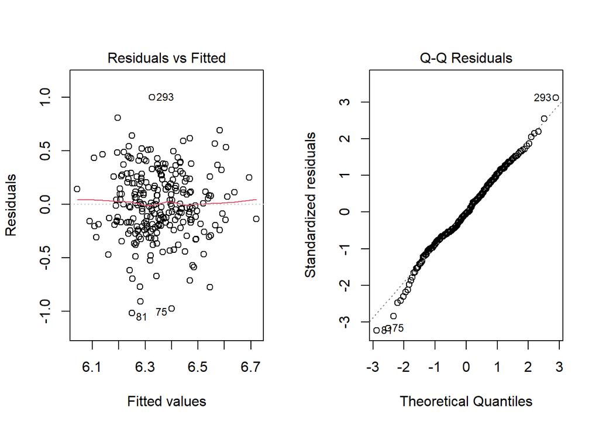

```r
par(mfrow = c(1, 2))
plot(fit_test2,which=1:2)
```

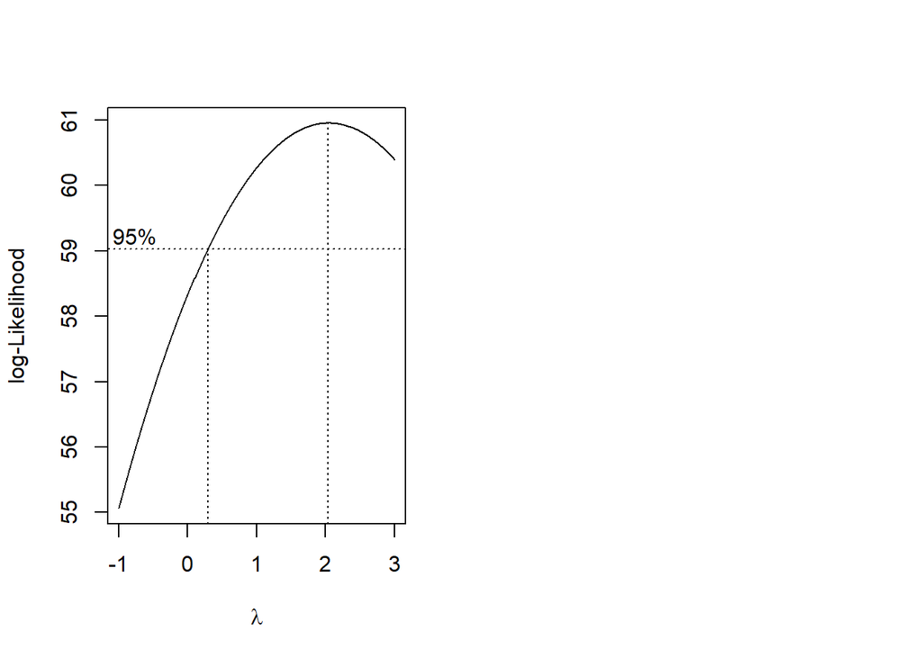

```r
boxcox(fit_test2, lambda = seq(-1, 3, 0.01))
```

**We don’t need extra transformation for $Y_{new}, since** $\lambda = 1$ is in the $95\%$ confidence interval.

Based on the residuals vs fitted values plot, we need to add some interaction terms or quadratic terms in to the first-order model.

```r
# full model
fit_full_all2 = lm(RETPLASMA_log ~ ((AGE + QUETELET + FAT + FIBER + CHOLESTEROL + BETADIET + RETDIET)^2 +
      I(AGE^2) + I(QUETELET^2) + I(FAT^2) + I(FIBER^2) + I(CHOLESTEROL^2) +
      I(BETADIET^2) + I(RETDIET^2)) *
      (ALCOHOL_Category + SEX + SMOKSTAT + VITUSE),
    data = train_data2)

#summary(fit_full_all2)
```

```r
# full model without interaction terms
fit_full2 = lm(RETPLASMA_log ~ (AGE + QUETELET + FAT + FIBER + CHOLESTEROL + BETADIET + RETDIET +
      I(AGE^2) + I(QUETELET^2) + I(FAT^2) + I(FIBER^2) + I(CHOLESTEROL^2) +
      I(BETADIET^2) + I(RETDIET^2)) *
      (ALCOHOL_Category + SEX + SMOKSTAT + VITUSE),
    data = train_data2)

#summary(fit_full2)
```

## 3-2. Model Search for RETPLASMA

### 3-2-1. AIC

Since the number of X variables is quite large and variables containing interaction terms and quadratic terms may have multicollinearity, we should use forward stepwise procedures to search local best model.

```r
scope_formula2 <- as.formula(
  "~ ((AGE + QUETELET + FAT + FIBER + CHOLESTEROL + BETADIET + RETDIET)^2 +
      I(AGE^2) + I(QUETELET^2) + I(FAT^2) + I(FIBER^2) + I(CHOLESTEROL^2) +
      I(BETADIET^2) + I(RETDIET^2)) *
      (ALCOHOL_Category + SEX + SMOKSTAT + VITUSE)"
)

null_model2 <- lm(RETPLASMA_log ~ 1, data = train_data2)

# forward stepwise procedures
best_model_aic2 <- stepAIC(null_model2,
                          scope = list(upper = scope_formula2, lower = ~1),
                          direction = "both",  # forward stepwise procedures
                          k = 2,
                          trace = FALSE)

# checking the best model with criterion AIC
best_model_aic2$anova
```

```
## Stepwise Model Path
## Analysis of Deviance Table
##
## Initial Model:
## RETPLASMA_log ~ 1
##
## Final Model:
## RETPLASMA_log ~ AGE + ALCOHOL_Category + I(BETADIET^2) + BETADIET
##
##
##                 Step Df  Deviance Resid. Df Resid. Dev       AIC
## 1                                       250   28.23793 -546.3815
## 2              + AGE  1 1.2009702       249   27.03696 -555.2903
## 3 + ALCOHOL_Category  2 1.2478933       247   25.78906 -563.1511
## 4    + I(BETADIET^2)  1 0.2896862       246   25.49938 -563.9865
## 5         + BETADIET  1 0.5387312       245   24.96065 -567.3463
```

```r
summary(best_model_aic2)
```

```
##
## Call:
## lm(formula = RETPLASMA_log ~ AGE + ALCOHOL_Category + I(BETADIET^2) +
##     BETADIET, data = train_data2)
##
## Residuals:
##      Min       1Q   Median       3Q      Max
## -1.09669 -0.20560 -0.00753  0.20639  0.97390
##
## Coefficients:
##                        Estimate Std. Error t value Pr(>|t|)
## (Intercept)             6.24888    0.03731 167.497  < 2e-16 ***
## AGE                     0.08777    0.02126   4.129 4.99e-05 ***
## ALCOHOL_CategoryNormal  0.07839    0.04610   1.700 0.090318 .
## ALCOHOL_CategoryHeavy   0.24176    0.06614   3.655 0.000314 ***
## I(BETADIET^2)           0.03040    0.01091   2.787 0.005738 **
## BETADIET               -0.06241    0.02714  -2.300 0.022316 *
## ---
## Signif. codes:  0 '***' 0.001 '**' 0.01 '*' 0.05 '.' 0.1 ' ' 1
##
## Residual standard error: 0.3192 on 245 degrees of freedom
## Multiple R-squared:  0.1161, Adjusted R-squared:  0.09802
## F-statistic: 6.434 on 5 and 245 DF,  p-value: 1.226e-05
```

```r
vif_values <- vif(best_model_aic2)
print(vif_values)
```

```
##                      GVIF Df GVIF^(1/(2*Df))
## AGE              1.108647  1        1.052923
## ALCOHOL_Category 1.083736  2        1.020307
## I(BETADIET^2)    1.791307  1        1.338397
## BETADIET         1.807489  1        1.344429
```

Try to do stepwise again to find a better model

```r
optimized_model <- stepAIC(best_model_aic2, direction = "both")
```

```
## Start:  AIC=-567.35
## RETPLASMA_log ~ AGE + ALCOHOL_Category + I(BETADIET^2) + BETADIET
##
##                    Df Sum of Sq    RSS     AIC
## <none>                          24.961 -567.35
## - BETADIET          1   0.53873 25.499 -563.99
## - I(BETADIET^2)     1   0.79130 25.752 -561.51
## - ALCOHOL_Category  2   1.36372 26.324 -557.99
## - AGE               1   1.73720 26.698 -552.46
```

```r
summary(optimized_model)
```

```
##
## Call:
## lm(formula = RETPLASMA_log ~ AGE + ALCOHOL_Category + I(BETADIET^2) +
##     BETADIET, data = train_data2)
##
## Residuals:
##      Min       1Q   Median       3Q      Max
## -1.09669 -0.20560 -0.00753  0.20639  0.97390
##
## Coefficients:
##                        Estimate Std. Error t value Pr(>|t|)
## (Intercept)             6.24888    0.03731 167.497  < 2e-16 ***
## AGE                     0.08777    0.02126   4.129 4.99e-05 ***
## ALCOHOL_CategoryNormal  0.07839    0.04610   1.700 0.090318 .
## ALCOHOL_CategoryHeavy   0.24176    0.06614   3.655 0.000314 ***
## I(BETADIET^2)           0.03040    0.01091   2.787 0.005738 **
## BETADIET               -0.06241    0.02714  -2.300 0.022316 *
## ---
## Signif. codes:  0 '***' 0.001 '**' 0.01 '*' 0.05 '.' 0.1 ' ' 1
##
## Residual standard error: 0.3192 on 245 degrees of freedom
## Multiple R-squared:  0.1161, Adjusted R-squared:  0.09802
## F-statistic: 6.434 on 5 and 245 DF,  p-value: 1.226e-05
```

There was no improvement after using the stepwise method again

### 3-2-2. BIC

```r
scope_formula3 <- as.formula(
  "~ ((AGE + QUETELET + FAT + FIBER + CHOLESTEROL + BETADIET + RETDIET)^2 +
      I(AGE^2) + I(QUETELET^2) + I(FAT^2) + I(FIBER^2) + I(CHOLESTEROL^2) +
      I(BETADIET^2) + I(RETDIET^2)) *
      (ALCOHOL_Category + SEX + SMOKSTAT + VITUSE)"
)

null_model3 <- lm(RETPLASMA_log ~ 1, data = train_data2)

# forward stepwise procedures
best_model_bic2 <- stepAIC(null_model3,
                          scope = list(upper = scope_formula3, lower = ~1),
                          direction = "both",  # forward stepwise procedures
                          k = log(nrow(train_data2)),
                          trace = FALSE)

# checking the best model with criterion BIC
best_model_bic2$anova
```

```
## Stepwise Model Path
## Analysis of Deviance Table
##
## Initial Model:
## RETPLASMA_log ~ 1
##
## Final Model:
## RETPLASMA_log ~ AGE + ALCOHOL_Category
##
##
##                 Step Df Deviance Resid. Df Resid. Dev       AIC
## 1                                      250   28.23793 -542.8561
## 2              + AGE  1 1.200970       249   27.03696 -548.2394
## 3 + ALCOHOL_Category  2 1.247893       247   25.78906 -549.0493
```

```r
summary(best_model_bic2)
```

```
##
## Call:
## lm(formula = RETPLASMA_log ~ AGE + ALCOHOL_Category, data = train_data2)
##
## Residuals:
##      Min       1Q   Median       3Q      Max
## -1.12320 -0.19896 -0.00996  0.20967  1.02712
##
## Coefficients:
##                        Estimate Std. Error t value Pr(>|t|)
## (Intercept)             6.28057    0.03604 174.255  < 2e-16 ***
## AGE                     0.07807    0.02119   3.684 0.000282 ***
## ALCOHOL_CategoryNormal  0.07860    0.04663   1.686 0.093140 .
## ALCOHOL_CategoryHeavy   0.23019    0.06674   3.449 0.000661 ***
## ---
## Signif. codes:  0 '***' 0.001 '**' 0.01 '*' 0.05 '.' 0.1 ' ' 1
##
## Residual standard error: 0.3231 on 247 degrees of freedom
## Multiple R-squared:  0.08672,    Adjusted R-squared:  0.07563
## F-statistic: 7.818 on 3 and 247 DF,  p-value: 5.253e-05
```

```r
# Compairing final model selected by AIC and BIC
anova(best_model_bic2, optimized_model)
```

```
## Analysis of Variance Table
##
## Model 1: RETPLASMA_log ~ AGE + ALCOHOL_Category
## Model 2: RETPLASMA_log ~ AGE + ALCOHOL_Category + I(BETADIET^2) + BETADIET
##   Res.Df    RSS Df Sum of Sq      F  Pr(>F)
## 1    247 25.789
## 2    245 24.961  2   0.82842 4.0656 0.01832 *
## ---
## Signif. codes:  0 '***' 0.001 '**' 0.01 '*' 0.05 '.' 0.1 ' ' 1
```

according to the anova result, we can see adding extra variables is significant, so we should choose model searched by AIC.

```r
final_model_RETPLASMA = optimized_model
summary(final_model_RETPLASMA)
```

```
##
## Call:
## lm(formula = RETPLASMA_log ~ AGE + ALCOHOL_Category + I(BETADIET^2) +
##     BETADIET, data = train_data2)
##
## Residuals:
##      Min       1Q   Median       3Q      Max
## -1.09669 -0.20560 -0.00753  0.20639  0.97390
##
## Coefficients:
##                        Estimate Std. Error t value Pr(>|t|)
## (Intercept)             6.24888    0.03731 167.497  < 2e-16 ***
## AGE                     0.08777    0.02126   4.129 4.99e-05 ***
## ALCOHOL_CategoryNormal  0.07839    0.04610   1.700 0.090318 .
## ALCOHOL_CategoryHeavy   0.24176    0.06614   3.655 0.000314 ***
## I(BETADIET^2)           0.03040    0.01091   2.787 0.005738 **
## BETADIET               -0.06241    0.02714  -2.300 0.022316 *
## ---
## Signif. codes:  0 '***' 0.001 '**' 0.01 '*' 0.05 '.' 0.1 ' ' 1
##
## Residual standard error: 0.3192 on 245 degrees of freedom
## Multiple R-squared:  0.1161, Adjusted R-squared:  0.09802
## F-statistic: 6.434 on 5 and 245 DF,  p-value: 1.226e-05
```

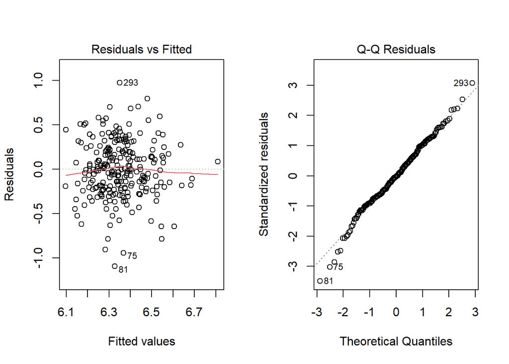

```r
par(mfrow = c(1, 2))
plot(optimized_model,which=1:2)
```

Visualization

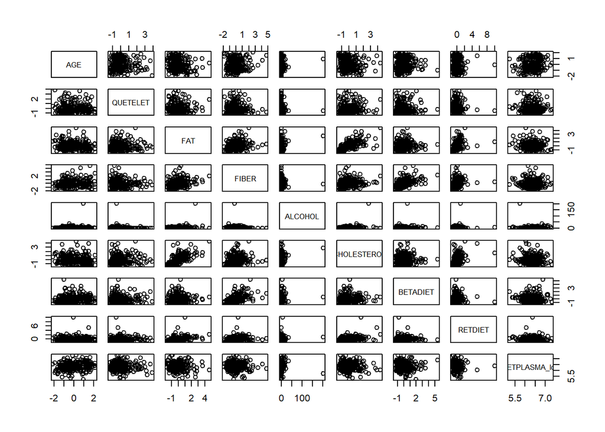

```r
par(mfrow = c(1, 1))
pairs(train_data2[,c(4:11,16)])
```

```r
cor(train_data2[,c(4:11,16)])
```

```
##                       AGE     QUETELET         FAT        FIBER      ALCOHOL
## AGE            1.00000000 -0.026501447 -0.15332750  0.064723748  0.041872068
## QUETELET      -0.02650145  1.000000000  0.04189803 -0.077254803 -0.084547236
## FAT           -0.15332750  0.041898030  1.00000000  0.288976882  0.203719086
## FIBER          0.06472375 -0.077254803  0.28897688  1.000000000 -0.009866584
## ALCOHOL        0.04187207 -0.084547236  0.20371909 -0.009866584  1.000000000
## CHOLESTEROL   -0.08570560  0.114144198  0.68125009  0.174583321  0.211456967
## BETADIET       0.09347254 -0.004247744  0.09473891  0.505262142  0.063591933
## RETDIET        0.02406129  0.030527025  0.38018813  0.218301442  0.055302051
## RETPLASMA_log  0.20622898 -0.041357535 -0.09410061 -0.037837415 -0.029846722
##               CHOLESTEROL     BETADIET     RETDIET RETPLASMA_log
## AGE           -0.08570560  0.093472541  0.02406129   0.206228985
## QUETELET       0.11414420 -0.004247744  0.03052702  -0.041357535
## FAT            0.68125009  0.094738907  0.38018813  -0.094100610
## FIBER          0.17458332  0.505262142  0.21830144  -0.037837415
## ALCOHOL        0.21145697  0.063591933  0.05530205  -0.029846722
## CHOLESTEROL    1.00000000  0.095408733  0.41292107  -0.046076182
## BETADIET       0.09540873  1.000000000  0.06550322  -0.003364344
## RETDIET        0.41292107  0.065503224  1.00000000  -0.032017663
## RETPLASMA_log -0.04607618 -0.003364344 -0.03201766   1.000000000
```

## 3-3. Model Validation for RETPLASMA

The final model is RETPLASMA_log ~ AGE + ALCOHOL_Category + BETADIET + BETADIET^2.

### 3-3-1. External validation

```r
# Mean Squared Prediction Error (MSPE)
actual_values2 <- validation_data2$RETPLASMA_log
predicted_values2 <- predict(final_model_RETPLASMA, newdata = validation_data2)
MSPE2 = sum((actual_values2 - predicted_values2)^2) / nrow(validation_data2)
MSPE2
```

```
## [1] 0.1103986
```

```r
SSE2 = sum((final_model_RETPLASMA$residuals)^2)
SSE2/nrow(train_data2)
```

```
## [1] 0.09944481
```

Since $MSPE$ is not much larger than $\frac{SSE}{n}$, this indicates no severe over-fitting by the model.

### 3-3-2. internal validation

```r
# Mallows' Cp
p_2 = length(coef(final_model_RETPLASMA))
sigma2_2 = summary(final_model_RETPLASMA)$sigma^2
Cp_2 = SSE2/sigma2_2 - (nrow(train_data2) - 2 * p_2)
Cp_2
```

```
## [1] 6
```

```r
p_2
```

```
## [1] 6
```

```r
# PRESSp
residuals2 <- resid(final_model_RETPLASMA)
h2 <- hatvalues(final_model_RETPLASMA)
PRESSp2 <- sum((residuals2 / (1 - h2))^2)
PRESSp2
```

```
## [1] 26.173
```

```r
SSE2
```

```
## [1] 24.96065
```

We have
$$C_p = 6, p = 6\quad and \quad
Press_p = 26.173, SSE_p = 24.96065$$
Since $C_p$ is not much larger than $p$ and $Press_p$ is not much larger than $SSE_p$, we can say there is no severe over-fitting and no substantial model bias.

### 3-3-3. Regression on the entire data

```r
data_entire2 = rbind(train_data2,validation_data2)
Model.2e = lm(RETPLASMA_log ~ AGE + ALCOHOL_Category + I(BETADIET^2) + BETADIET, data = data_entire2)
summary(Model.2e)
```

```
##
## Call:
## lm(formula = RETPLASMA_log ~ AGE + ALCOHOL_Category + I(BETADIET^2) +
##     BETADIET, data = data_entire2)
##
## Residuals:
##     Min      1Q  Median      3Q     Max
## -1.0743 -0.2021  0.0003  0.2037  0.9930
##
## Coefficients:
##                        Estimate Std. Error t value Pr(>|t|)
## (Intercept)             6.24720    0.03268 191.155  < 2e-16 ***
## AGE                     0.08608    0.01881   4.577 6.86e-06 ***
## ALCOHOL_CategoryNormal  0.08753    0.04043   2.165 0.031138 *
## ALCOHOL_CategoryHeavy   0.21996    0.05897   3.730 0.000228 ***
## I(BETADIET^2)           0.02630    0.01047   2.512 0.012525 *
## BETADIET               -0.06389    0.02468  -2.588 0.010102 *
## ---
## Signif. codes:  0 '***' 0.001 '**' 0.01 '*' 0.05 '.' 0.1 ' ' 1
##
## Residual standard error: 0.3215 on 308 degrees of freedom
## Multiple R-squared:  0.1074, Adjusted R-squared:  0.09295
## F-statistic: 7.415 on 5 and 308 DF,  p-value: 1.387e-06
```

## 3-4. Model Explanation for RETPLASMA

Even though the $R^2$ is quite small in this regression model, we can try to find some relationship between response variable and predictors.

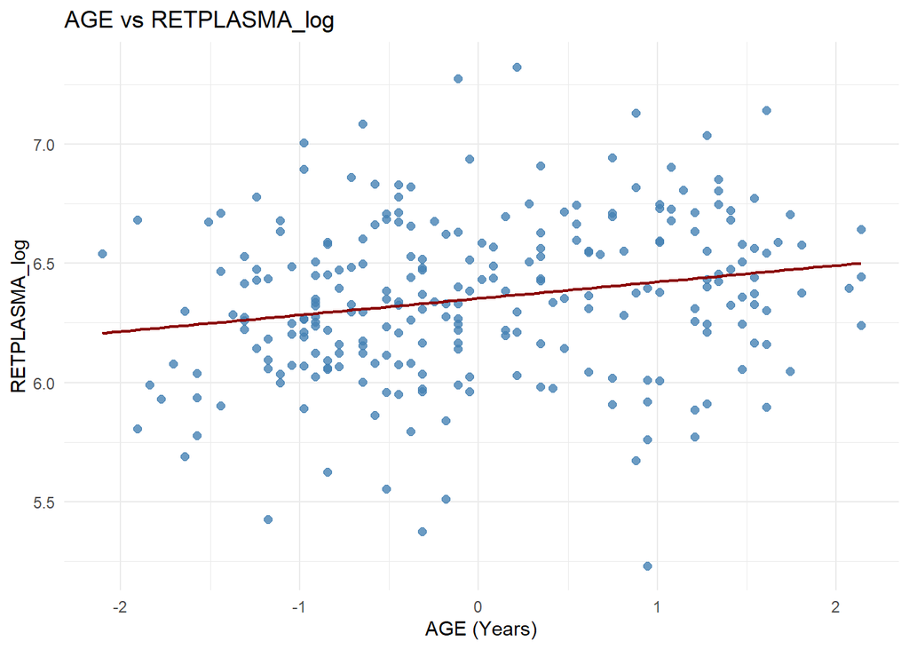

```r
# 1. The relationship between continuous variable and dependent variable
# AGE 与 RETPLASMA_log
ggplot(train_data2, aes(x = AGE, y = RETPLASMA_log)) +
  geom_point(size = 2, alpha = 0.8, color = "steelblue") +
  geom_smooth(method = "lm", se = FALSE, color = "darkred", size = 0.8) +
  labs(title = "AGE vs RETPLASMA_log", x = "AGE (Years)", y = "RETPLASMA_log") +
  theme_minimal()
```

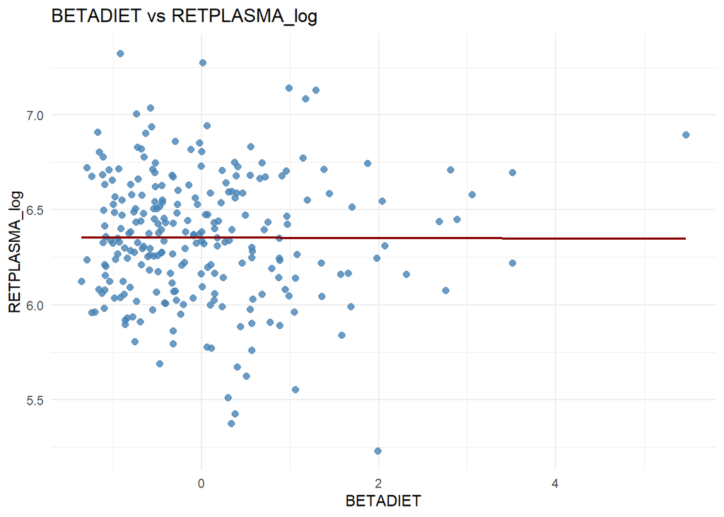

```r
# BETADIET 与 RETPLASMA_log
ggplot(train_data2, aes(x = BETADIET, y = RETPLASMA_log)) +
  geom_point(size = 2, alpha = 0.8, color = "steelblue") +
  geom_smooth(method = "lm", se = FALSE, color = "darkred", size = 0.8) +
  labs(title = "BETADIET vs RETPLASMA_log", x = "BETADIET", y = "RETPLASMA_log") +
  theme_minimal()
```

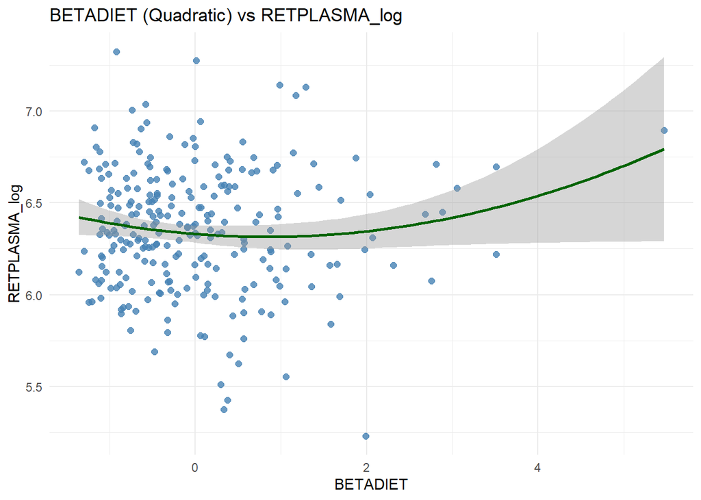

```r
# 2. Relationship between nonlinear variable (BETADIET^2) and dependent variable
ggplot(train_data2, aes(x = BETADIET, y = RETPLASMA_log)) +
  geom_point(size = 2, alpha = 0.8, color = "steelblue") +
  stat_smooth(method = "lm", formula = y ~ poly(x, 2), color = "darkgreen", size = 1) +
  labs(title = "BETADIET (Quadratic) vs RETPLASMA_log", x = "BETADIET", y = "RETPLASMA_log") +
  theme_minimal()
```

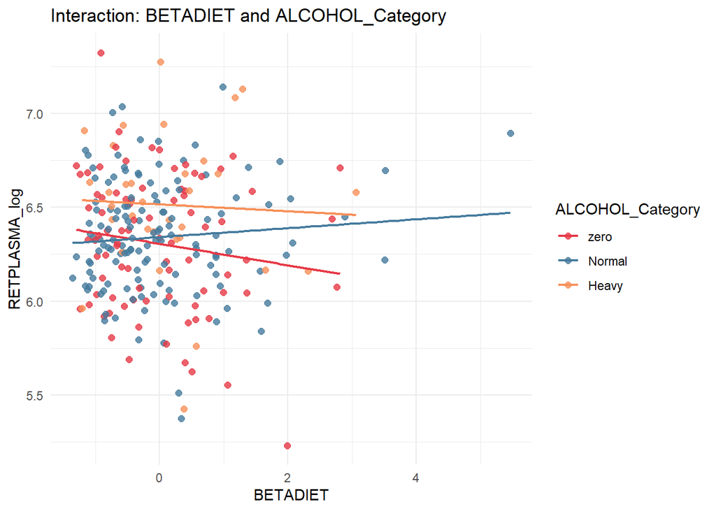

```r
# 3. Visualization of categorical variables and interaction terms
ggplot(train_data2, aes(x = BETADIET, y = RETPLASMA_log, color = ALCOHOL_Category)) +
  geom_point(size = 2, alpha = 0.8) +
  geom_smooth(method = "lm", se = FALSE, size = 0.8) +
  labs(title = "Interaction: BETADIET and ALCOHOL_Category", x = "BETADIET", y = "RETPLASMA_log") +
  scale_color_manual(values = c("#E63946", "#457B9D", "#f79059")) +
  theme_minimal()
```

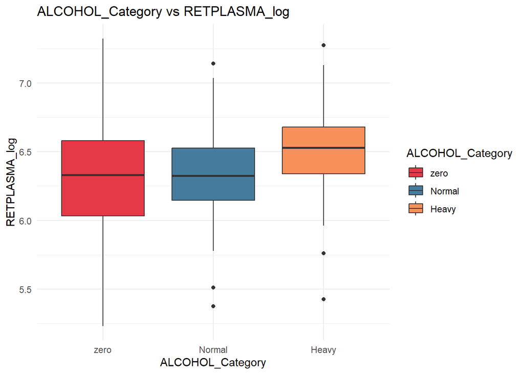

```r
# 4. Box plot of categorical variables
ggplot(train_data2, aes(x = ALCOHOL_Category, y = RETPLASMA_log, fill = ALCOHOL_Category)) +
  geom_boxplot() +
  scale_fill_manual(values = c("#E63946", "#457B9D", "#f79059")) +
  labs(title = "ALCOHOL_Category vs RETPLASMA_log", x = "ALCOHOL_Category", y = "RETPLASMA_log") +
  theme_minimal()
```

## 4. model diagnostics (Outlyer Analysis)

After construct the model for two response variables, let’s consider if there exists some influencial outlyers in out database.

### y outlyer

For BETAPLASMA_log

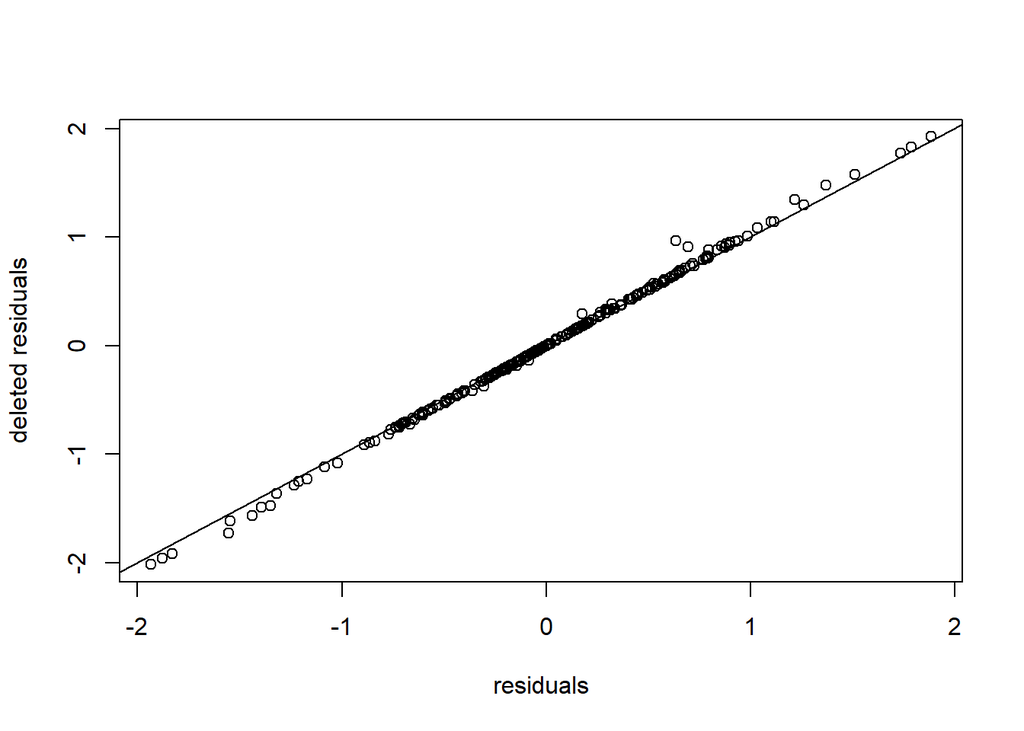

```r
e<-final_model_aic$residuals ##ordinary residuals
h<-influence(final_model_aic)$hat ##diagonals of the hat matrix: a.k.a. leverage values
de<-e/(1-h) ##deleted residuals
plot(e,de, xlab="residuals", ylab="deleted residuals")
abline(0,1)
```

```r
summary(h)
```

```
##    Min. 1st Qu.  Median    Mean 3rd Qu.    Max.
## 0.01601 0.02699 0.03656 0.04781 0.04955 0.40558
```

```r
#studentized deleted residuals
library(MASS)
stu.res.del <- studres(final_model_aic)
head(sort(abs(stu.res.del), decreasing=TRUE))
```

```
##      233       97      208      139      262      178
## 3.137491 3.047328 3.019624 2.969379 2.862325 2.772372
```

```r
stu.res.del <- studres(final_model_aic)
head(sort(abs(stu.res.del), decreasing=TRUE))
```

```
##      233       97      208      139      262      178
## 3.137491 3.047328 3.019624 2.969379 2.862325 2.772372
```

```r
# Bonferroni 's Threshold
n = nrow(train_data2)
p = length(coef(final_model_aic))
qt(1-0.1/(2*n), n-p-1) #Bonferroni's Threshold (alpha=0.1, n=sample size)
```

```
## [1] 3.592151
```

1. Based on the scatter plot, we can see when we delete single case, the delete residual do not change significantly comparing to the residual. Thus, there is no outlyer in Y.
2. And there is no T statistic larger than Bonferroni ’s Threshold, so there is no outlyer in Y.

### X outlyer

For BETAPLASMA_log:

We can use leverage to check outlying in X.

```r
# checking case which is larger than 2p/n
h <- influence(final_model_aic)$hat
p <- length(coef(final_model_aic))
sort(h[which(h>2*p/n)], decreasing = TRUE)
```

```
##        263        309        152         28         94        144        230
## 0.40557607 0.37537505 0.34488260 0.23778865 0.21111671 0.17947403 0.16829299
##         73        313          3        281        112         27         25
## 0.13725994 0.13619037 0.13228156 0.13096218 0.13083785 0.12500075 0.11112415
##         81         40
## 0.09849908 0.09614723
```

```r
# Calculating Cook's distance
res <- final_model_aic$residuals
mse <- anova(final_model_aic)["Residuals", 3]
cook.d <- res^2*h/(p*mse*(1-h)^2)

# identify influential cases
sort(cook.d[which(cook.d>4/(n-p))], decreasing = TRUE)
```

```
##        152         81        109         28         86         40        236
## 0.06569866 0.05934910 0.04112378 0.03989010 0.03879244 0.03522750 0.03335745
##        139        233         97        305         35        185
## 0.03327500 0.03314214 0.03267200 0.02965396 0.02198627 0.02198132
```

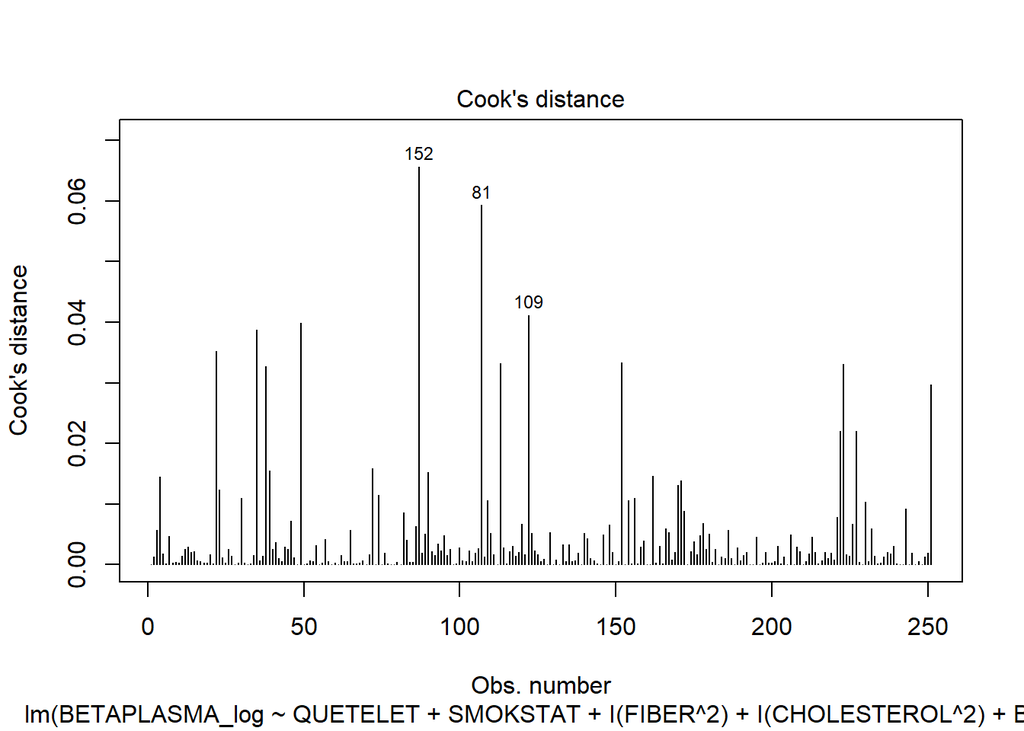

```r
# Cook’s distance plot
plot(final_model_aic, which=4)
```

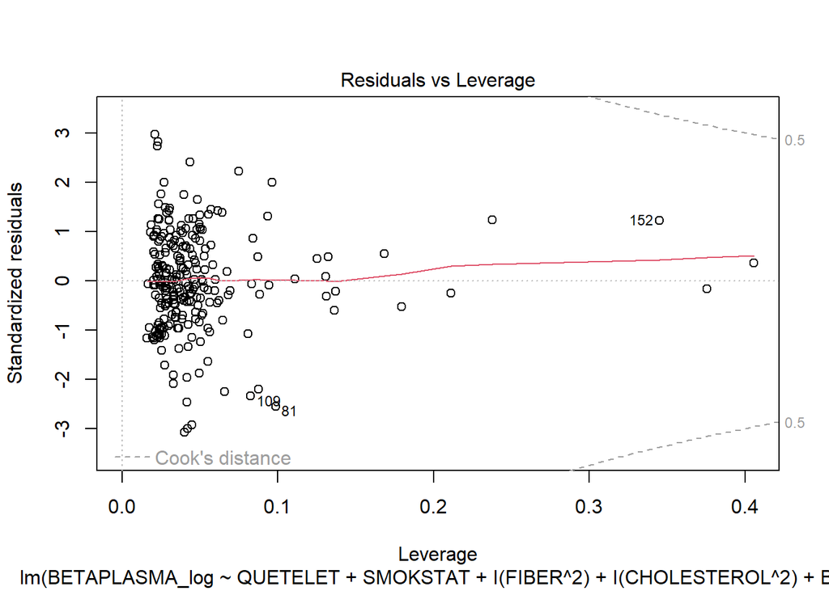

```r
# the Residuals vs. Leverage plot
plot(final_model_aic, which=5)
```

Based on the outputs, we can see the Cook’s distance is pretty small for all cases. But we can still try to remove the case labeled as “152”.

```r
which(rownames(train_data2)=="152")
```

```
## [1] 87
```

```r
fit.152 = lm(BETAPLASMA_log ~ QUETELET + SMOKSTAT + I(FIBER^2) +
    I(CHOLESTEROL^2) + BETADIET + VITUSE + AGE + BETADIET:VITUSE,
    data = train_data2, subset=setdiff(rownames(train_data2), "152"))

# compare regression coefficients
rbind(final_model_aic$coefficients,fit.152$coefficients)
```

```
##      (Intercept)   QUETELET SMOKSTATFORMER SMOKSTATNEVER I(FIBER^2)
## [1,]    4.474873 -0.2116961      0.2773704     0.4343961 0.03955625
## [2,]    4.502990 -0.2172675      0.2685441     0.4223572 0.03652711
##      I(CHOLESTEROL^2)    BETADIET VITUSENOT OFTEN VITUSEOFTEN       AGE
## [1,]      -0.04661177 -0.08483421       0.2926945   0.2227571 0.1009624
## [2,]      -0.06318209 -0.09006610       0.2852682   0.2185553 0.1032405
##      BETADIET:VITUSENOT OFTEN BETADIET:VITUSEOFTEN
## [1,]                0.1695839            0.3388352
## [2,]                0.1760230            0.3438326
```

As can be seen, there is little difference in these two fits, so here even the most influential case, namely case 152, can be retained.

Therefore, there is no influencial case in BETAPLASMA model.